# Flight Delays Prediction / Analytics

Sreekantha Thimmareddy

22 Nov 2017

## Objective

Have you ever been stuck in an airport because your flight was delayed or cancelled and wondered if you could have predicted it if you’d had more data? This is to answer few questions in the context of Airline on-time performance:

. Which Airlines/carrier performs better?

. When is the best time of day/day of week/time of year to fly to minimise delays?

. Do older planes suffer more delays?

. Can you detect cascading failures as delays in one airport create delays in others?

. Create a model to predict flight delays

Note: All the delays are represented in minutes. ##Installing all required packaes

```r
# Packages required
#install.packages("devtools")
#install.packages("rlang") # The package is failing hence using below frm github
#devtools::install_github("tidyverse/rlang", build_vignettes = TRUE)
#install.packages("shiny")
#install.packages("dbplyr")
#install.packages("digest")
#install.packages("backports")
#install.packages("sparklyr") #  If thee package is failing hence using below frm github
#devtools::install_github("rstudio/sparklyr")
#install.packages("sqldf")
#install.packages("corrplot")  # For plotting co-relation
#install.packages("Hmisc") # For co-relation and P values
#install.packages("MASS")  # StepAIC function to choose variables
#install.packages("caret")
#install.packages("R.utils")

library(corrplot)
library(R.utils)
library(sqldf)
library(data.table)
library(caret)
library(stats)
library(devtools)
library(rlang)
library(shiny)
library(dbplyr)
library(digest)
library(backports)
library(sparklyr)
library(ggplot2)  #the cookbook for R: http://www.cookbook-r.com/Graphs/
library(dplyr)
library(DBI)  # For SQL on
#library(MASS)
```

## Loading and Processing Data

```r
# Set Working dir
setwd("D:/Data Science/Flight Data Analysis/")
```

```r
#Download data from Web
#download.file(url="http://stat-computing.org/dataexpo/2009/2007.csv.bz2", destfile = "./Data/2007.csv.bz2")
#download.file(url="http://stat-computing.org/dataexpo/2009/2008.csv.bz2", destfile = "./Data/2008.csv.bz2")
#download.file(url="http://stat-computing.org/dataexpo/2009/airports.csv", destfile = "./Data/airports.csv")
#download.file(url="http://stat-computing.org/dataexpo/2009/carriers.csv", destfile = "./Data/carriers.csv")
#download.file(url="http://stat-computing.org/dataexpo/2009/plane-data.csv", destfile = "./Data/plane_data.csv")

# Unzip files
#bunzip2("./Data/new/2007.csv.bz2", "./Data/2007.csv", remove = FALSE, skip = TRUE)
#bunzip2("./Data/new/2008.csv.bz2", "./Data/2008.csv", remove = FALSE, skip = TRUE)

# Loading data files and working with sample set
# Loading data files and working with sample set
trips2007 <- fread("D:\\Data Science\\Flight Data Analysis\\Data\\2007.csv")  #Fastest way to load large files.

trips2007a <- sample_n(trips2007, 100000)
rm(trips2007)
trips2007a <- as.data.table(trips2007a)

trips2008 <- fread("D:\\Data Science\\Flight Data Analysis\\Data\\2008.csv")
trips2008b <- sample_n(trips2008, 100000)
rm(trips2008)
trips2008b <- as.data.table(trips2008b)

tripsfile <- rbind(trips2007a, trips2008b)

# To free up unused files.
rm(trips2007a, trips2008b)

## Load other supporting files as well. = ",",header = TRUE)
planedatafile <- read.csv2('D:\\Data Science\\Flight Data Analysis\\Data\\plane_data.csv',sep = ",",header = TRUE)
airportsfile <- read.csv2('D:\\Data Science\\Flight Data Analysis\\Data\\airports.csv',sep = ",",header = TRUE)
carriersfile <- read.csv2('D:\\Data Science\\Flight Data Analysis\\Data\\carriers.csv',sep = ",",header = TRUE)

## This is to have copy of raw data untouched available for any reference.


planedata <- planedatafile
airports <- airportsfile
carriers <- carriersfile
trips <- tripsfile
```

## Feature Engineering

```r
summary(trips,message=FALSE, warning=FALSE)
```

```
##       Year          Month          DayofMonth      DayOfWeek
##  Min.   :2007   Min.   : 1.000   Min.   : 1.00   Min.   :1.00
##  1st Qu.:2007   1st Qu.: 4.000   1st Qu.: 8.00   1st Qu.:2.00
##  Median :2008   Median : 6.000   Median :16.00   Median :4.00
##  Mean   :2008   Mean   : 6.458   Mean   :15.74   Mean   :3.93
##  3rd Qu.:2008   3rd Qu.: 9.000   3rd Qu.:23.00   3rd Qu.:6.00
##  Max.   :2008   Max.   :12.000   Max.   :31.00   Max.   :7.00
##
##     DepTime       CRSDepTime      ArrTime       CRSArrTime
##  Min.   :   1   Min.   :   1   Min.   :   1   Min.   :   1
##  1st Qu.: 930   1st Qu.: 930   1st Qu.:1108   1st Qu.:1115
##  Median :1327   Median :1320   Median :1513   Median :1518
##  Mean   :1337   Mean   :1329   Mean   :1483   Mean   :1496
##  3rd Qu.:1730   3rd Qu.:1720   3rd Qu.:1910   3rd Qu.:1907
##  Max.   :2400   Max.   :2359   Max.   :2400   Max.   :2400
##  NA's   :3993                  NA's   :4448
##  UniqueCarrier        FlightNum      TailNum          ActualElapsedTime
##  Length:200000      Min.   :   1   Length:200000      Min.   : 15.0
##  Class :character   1st Qu.: 608   Class :character   1st Qu.: 76.0
##  Mode  :character   Median :1545   Mode  :character   Median :109.0
##                     Mean   :2211                      Mean   :127.1
##                     3rd Qu.:3555                      3rd Qu.:157.0
##                     Max.   :7829                      Max.   :772.0
##                                                       NA's   :4485
##  CRSElapsedTime     AirTime         ArrDelay           DepDelay
##  Min.   :  1.0   Min.   :  0.0   Min.   : -80.000   Min.   : -67.00
##  1st Qu.: 79.0   1st Qu.: 55.0   1st Qu.:  -9.000   1st Qu.:  -4.00
##  Median :110.0   Median : 85.0   Median :  -1.000   Median :  -1.00
##  Mean   :128.3   Mean   :103.6   Mean   :   9.133   Mean   :  10.63
##  3rd Qu.:158.0   3rd Qu.:132.0   3rd Qu.:  13.000   3rd Qu.:   9.00
##  Max.   :660.0   Max.   :753.0   Max.   :1351.000   Max.   :1360.00
##  NA's   :26      NA's   :4485    NA's   :4485       NA's   :3993
##     Origin              Dest              Distance          TaxiIn
##  Length:200000      Length:200000      Min.   :  31.0   Min.   :  0.000
##  Class :character   Class :character   1st Qu.: 324.0   1st Qu.:  4.000
##  Mode  :character   Mode  :character   Median : 576.0   Median :  6.000
##                                        Mean   : 725.3   Mean   :  6.789
##                                        3rd Qu.: 950.0   3rd Qu.:  8.000
##                                        Max.   :4962.0   Max.   :545.000
##                                                         NA's   :2096
```

[output cut: 9 more lines]

```
##  Min.   :   0.00   Min.   :  0.00   Min.   :  0.00   Min.   :  0.00
##  1st Qu.:   0.00   1st Qu.:  0.00   1st Qu.:  0.00   1st Qu.:  0.00
##  Median :   0.00   Median :  0.00   Median :  0.00   Median :  0.00
##  Mean   :   5.97   Mean   :  1.17   Mean   :  6.23   Mean   :  0.03
##  3rd Qu.:   0.00   3rd Qu.:  0.00   3rd Qu.:  0.00   3rd Qu.:  0.00
##  Max.   :1351.00   Max.   :710.00   Max.   :872.00   Max.   :170.00
##  NA's   :78279     NA's   :78279    NA's   :78279    NA's   :78279
##  LateAircraftDelay
##  Min.   :  0.00
##  1st Qu.:  0.00
##  Median :  0.00
##  Mean   :  7.77
##  3rd Qu.:  0.00
##  Max.   :889.00
##  NA's   :78279
```

```r
head(filter(trips,  WeatherDelay == 0 ))
```

```
##   Year Month DayofMonth DayOfWeek DepTime CRSDepTime ArrTime CRSArrTime
## 1 2007     4         10         2    1821       1825    1856       1900
## 2 2007     5         30         3    1200       1200    1517       1519
## 3 2007    11          2         5    1454       1455    1613       1614
## 4 2007    11         16         5     953        955    1159       1220
## 5 2007     8         25         6     759        805    1040       1049
## 6 2007     7         20         5     655        700    1001       1010
##   UniqueCarrier FlightNum TailNum ActualElapsedTime CRSElapsedTime AirTime
## 1            AA      1701  N419AA               155            155     140
## 2            OH      5466  N669CA               137            139      99
## 3            OO      3898  N409SW                79             79      58
## 4            WN       171  N254WN               126            145     110
## 5            NW       479  N517US               161            164     132
## 6            UA       670  N904UA               126            130     106
##   ArrDelay DepDelay Origin Dest Distance TaxiIn TaxiOut Cancelled
```

[output cut: 20 more lines]

We can see there are ~40% of values are NAs for WeatherDelay, NASDelays, SecurityDelay, LateAircraftDelay. We cannot eaither mark them as zero or backfill with other value. It’s best to omit and use remaining data or exclude these variables in prediction. We can try both. And in other variables, small number of NAs present and we can omit them as well.

Creating hour variables as the time is in HHMM format and not suitable for analysis.

```r
trips$ArrHour <- trunc(trips$CRSArrTime/100)
trips$DepHour <- trunc(trips$CRSDepTime/100)
```

Deviding day into 4 time periods for analysis have devided 24 hours into 4 buckets. i.e new variables DepTimeOfDay, ArrTimeOfDay - 12am to 5:59 am as 0 (Night) - 6am to 11:59 am as 1 (Morning) - 12noon to 5:59pm (Afternoon) - 6pm to 11:59pm (Evening)

```r
trips$ArrTimeofday <- trunc(trips$ArrHour/6)
trips$DepTimeofday <- trunc(trips$DepHour/6)
```

To see week of month has any significance. It may.

```r
trips$WeekOfMonth <- trunc(trips$DayofMonth/7+1)
```

Clearly based on data, the dependent variables are DepDelay and ArrDelay which is the total delay. Adding week of month.

### Joining the supporting data set.

Now let us merge/join supporting data set. This is to make one big de-normalized flat table with all the data fields required available. This can be done after initial EDA as well to find out which fields ussually to be included/excluded. Since I did some exploration in previous versions of code so doing it ahead before EDA here. First Planedata, not all fields are important. Also need to delete any NAs as we don’t have source to backfill.

```r
planedatanew <- planedata[, c("tailnum","type","manufacturer","aircraft_type","engine_type","year") ]
planedatanew <- na.omit(filter(planedatanew, year != "" ))
planedatanew <- na.omit(planedatanew)

#Now Left join two tables
tripsplane <- merge(x=trips, y=planedatanew , by.x="TailNum", by.y="tailnum", all.x = TRUE)[]

# Now let's use airports

nrow(airports)
airportsnew <- na.omit(airports[, c("iata","city", "state", "country")])
nrow(airportsnew)

#Merging for Origin Airports
tripsplaneairports <- merge(x=tripsplane, y=airportsnew , by.x="Origin", by.y="iata", all.x = TRUE)[]
setnames(tripsplaneairports, old = c("city", "state", "country"), new= c("Origincity", "Originstate", "Origincountry"))

# Merging for Destination airports
tripsplaneairports <- merge(x=tripsplaneairports, y=airportsnew , by.x="Dest", by.y="iata", all.x = TRUE)[]

#Renaming the columns to reflect correctly
setnames(tripsplaneairports, old = c("city", "state", "country"), new= c("Destcity", "Deststate", "Destcountry"))

# Again some feature Engineering
tripsplaneairports$planeAge <-  tripsplaneairports$Year  - as.numeric(as.character(tripsplaneairports$year))
str(tripsplaneairports$planeAge)


# Let's create date out of year, month, Day of month

 tripsplaneairports$TravelDate <- as.Date(with(tripsplaneairports, paste(Year, Month, DayofMonth,sep="-")), "%Y-%m-%d")
```

## Exploratory Data Analysis

### Before EDA let’s set aside a set of data for independent evaluation of the model at the end.

```r
set.seed(110)
sub_ind <- sample(nrow(tripsplaneairports), floor(nrow(tripsplaneairports) * 0.2))

trips_ind <- tripsplaneairports[sub_ind,]
tripsplaneairports <- tripsplaneairports[-sub_ind,]
```

Let’s do EDA and find out significance of the variables in predicting Flight Delays For Continous variables, we can use co-relation to see how y is co-related to x1, x2 etc.. which is a good starting point to include in the model. For Categorical variables, let’s find if there are patterns.

Also, let us try and answer some of the questions we defined in the objective.

## Which Airlines/Carrier performs better ?

This is bit generic question. We can make an assumption that the ask is in terms of flight delays

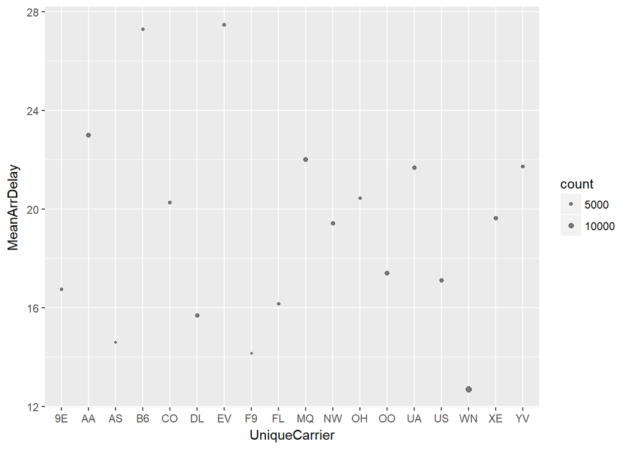

```r
CarrierDelay <- tripsplaneairports %>%
                  group_by(UniqueCarrier) %>%
                  summarise(count=n(), MeanArrDelay = mean(ArrDelay), MeanDepDelay=mean(DepDelay), MeanNASDelay=mean(NASDelay)) %>%
                  filter ( count > 1000, !is.na(MeanArrDelay), !is.na(MeanDepDelay) ) %>%
                  collect

#plot
ggplot(CarrierDelay, aes(UniqueCarrier, MeanArrDelay)) + geom_point(aes(size=count), alpha=1/2) +  scale_size_area(max_size = 2)
```

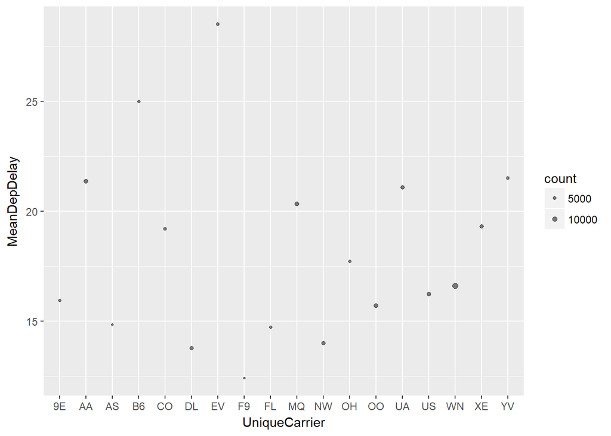

```r
ggplot(CarrierDelay, aes(UniqueCarrier, MeanDepDelay)) + geom_point(aes(size=count), alpha=1/2) +  scale_size_area(max_size = 2)
```

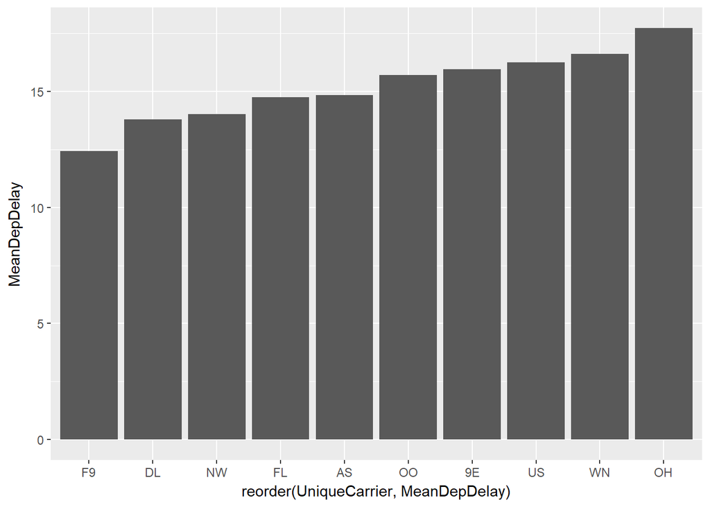

```r
# Same stuff with Bar chart.
CarrierDelay %>% top_n(n=10,- MeanDepDelay ) %>%
ggplot( aes(reorder(UniqueCarrier, MeanDepDelay), MeanDepDelay)) + geom_bar( stat = "identity")
```

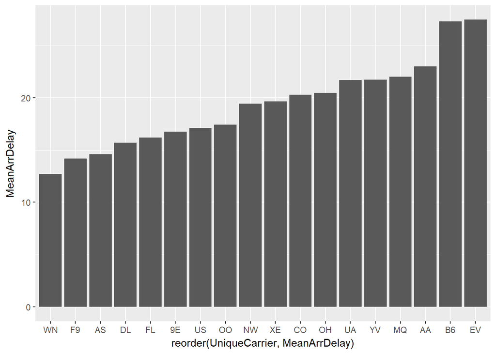

```r
ggplot(CarrierDelay, aes(reorder(UniqueCarrier, MeanArrDelay), MeanArrDelay)) + geom_bar( stat = "identity")
```

Again, Carrier performance differs between Airport to Airport. We can easily apply filter on Airport and get best parforming of Carrier. Or write a simple function to do the same.

#### Origin Airports - Performance

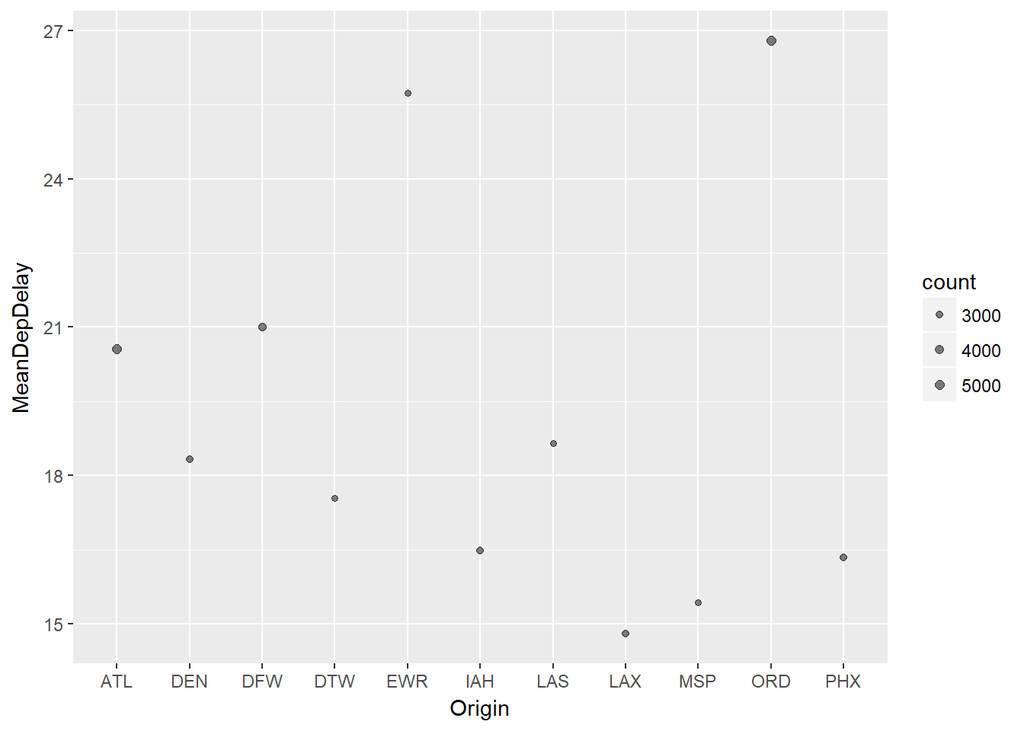

```r
OriginAirportDelay <- tripsplaneairports %>%
  group_by(Origin) %>%
  summarise(count=n(), MeanArrDelay = mean(ArrDelay), MeanDepDelay=mean(DepDelay), MeanWeatherDelay=mean(WeatherDelay)) %>%
  filter ( count > 2000, !is.na(MeanArrDelay), !is.na(MeanDepDelay) ) %>%
  collect
# Increasing count to 2000 for filtering in order to avoid too much cluttering.

#plot
ggplot(OriginAirportDelay, aes(Origin, MeanDepDelay)) + geom_point(aes(size=count), alpha=1/2) + geom_smooth() + scale_size_area(max_size = 2)
```

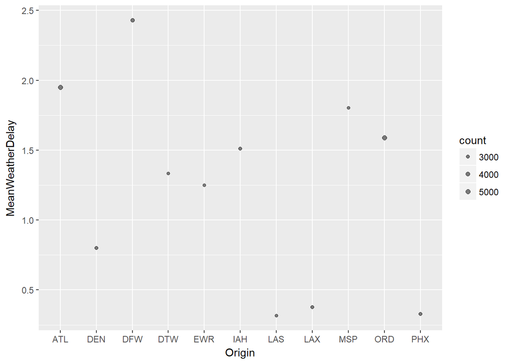

```r
ggplot(OriginAirportDelay, aes(Origin, MeanWeatherDelay)) + geom_point(aes(size=count), alpha=1/2) + geom_smooth() + scale_size_area(max_size = 2)
```

Lax doing better for Departure. Weather is also not much impacted at LAX compared to others. However, except these airports, there is no perticular pattern we can observe. May be we need to combine other variables.

##### Dest Airports - performance

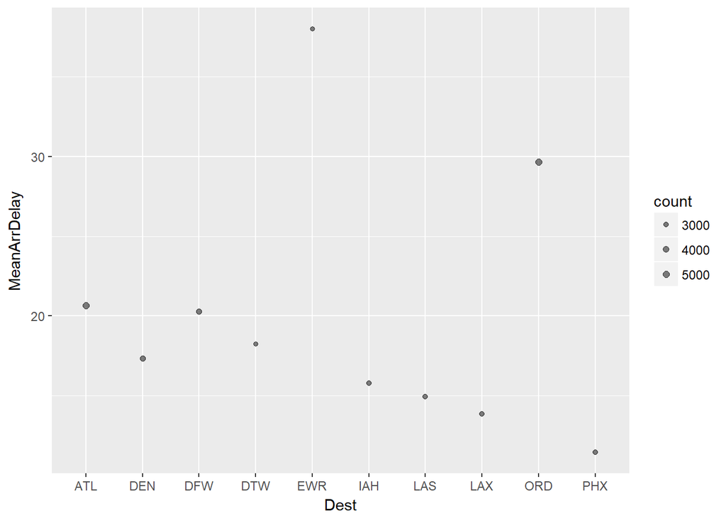

```r
DestAirportDelay <- tripsplaneairports %>%
  group_by(Dest) %>%
  summarise(count=n(), MeanArrDelay = mean(ArrDelay), MeanDepDelay=mean(DepDelay), MeanWeatherDelay2=mean(WeatherDelay)) %>%
  filter ( count > 2000, !is.na(MeanArrDelay), !is.na(MeanDepDelay) ) %>%
  collect
#
#plot
ggplot(DestAirportDelay, aes(Dest, MeanArrDelay)) + geom_point(aes(size=count), alpha=1/2) + geom_smooth() + scale_size_area(max_size = 2)
```

PHX are doing very good with Arrival. And ORD is not so great.

## When is the best time of the day/week/month/year to travel to minimize delays ?

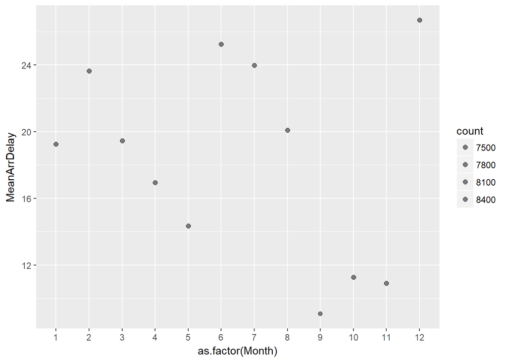

```r
DayMonthDelay <- tripsplaneairports %>%
  group_by(Month) %>%
  summarise(count=n(), MeanArrDelay = mean(ArrDelay), MeanDepDelay=mean(DepDelay), MeanWeatherDelay2=mean(WeatherDelay)) %>%
  filter ( count > 50, !is.na(MeanArrDelay), !is.na(MeanDepDelay) ) %>%
  collect

#plot
ggplot(DayMonthDelay, aes(as.factor(Month), MeanArrDelay)) + geom_point(aes(size=count), alpha=1/2) + geom_smooth() + scale_size_area(max_size = 2)
```

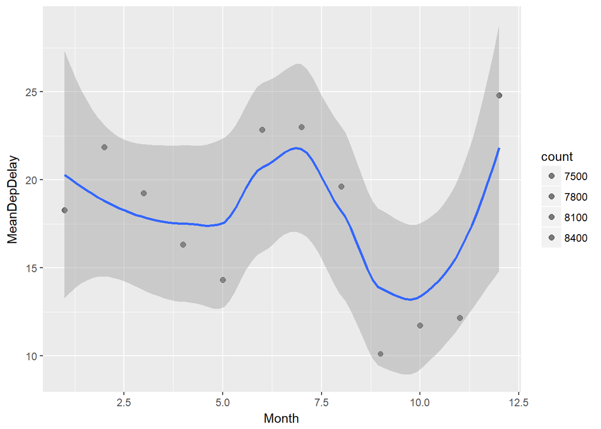

```r
ggplot(DayMonthDelay, aes(Month, MeanDepDelay)) + geom_point(aes(size=count), alpha=1/2) + geom_smooth() + scale_size_area(max_size = 2)
```

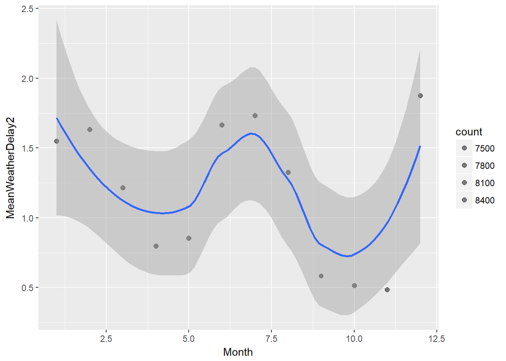

```r
ggplot(DayMonthDelay, aes(Month, MeanWeatherDelay2)) + geom_point(aes(size=count), alpha=1/2) + geom_smooth() + scale_size_area(max_size = 2)
```

We can clearly see Sept, Oct, Nov are the best months to fly as the delays are very min.

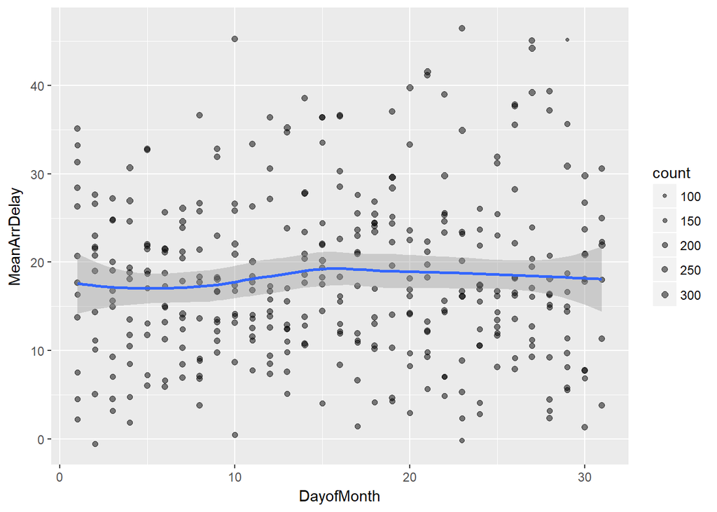

```r
DayofMonthDelay <- tripsplaneairports %>%
  group_by(Month,DayofMonth) %>%
  summarise(count=n(), MeanArrDelay = mean(ArrDelay), MeanDepDelay=mean(DepDelay), MeanWeatherDelay2=mean(WeatherDelay)) %>%
  filter ( count > 50, !is.na(MeanArrDelay), !is.na(MeanDepDelay) ) %>%
  collect

ggplot(DayofMonthDelay, aes(DayofMonth, MeanArrDelay)) + geom_point(aes(size=count), alpha=1/2) + geom_smooth() + scale_size_area(max_size = 2)
```

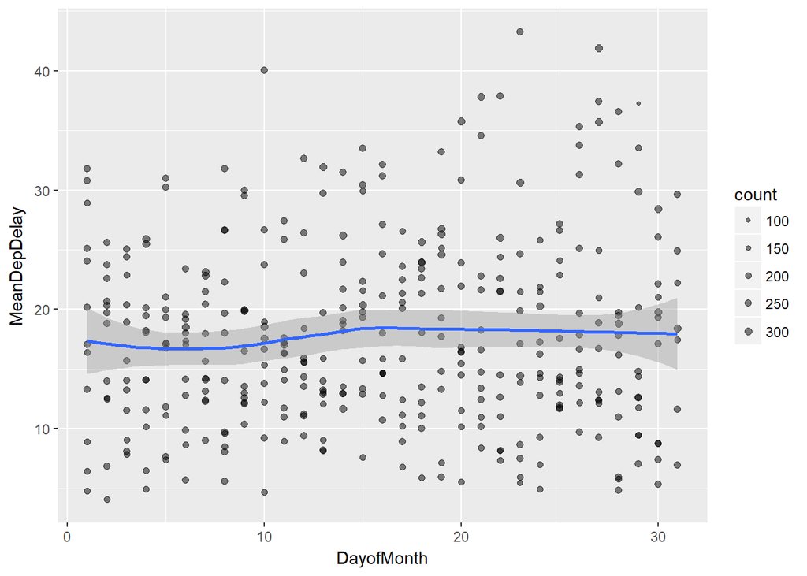

```r
ggplot(DayofMonthDelay, aes(DayofMonth, MeanDepDelay)) + geom_point(aes(size=count), alpha=1/2) + geom_smooth() + scale_size_area(max_size = 2)
```

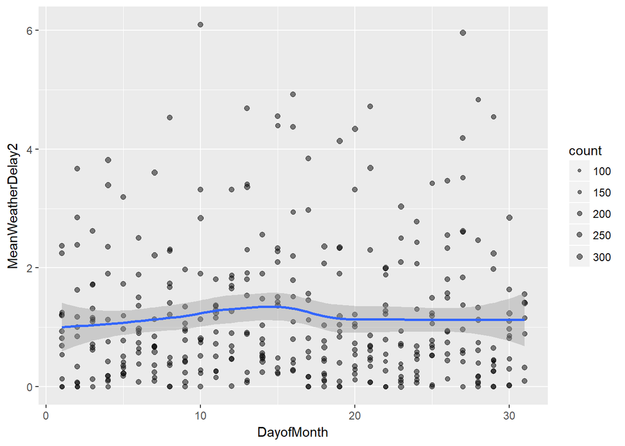

```r
ggplot(DayofMonthDelay, aes(DayofMonth, MeanWeatherDelay2)) + geom_point(aes(size=count), alpha=1/2) + geom_smooth() + scale_size_area(max_size = 2)
```

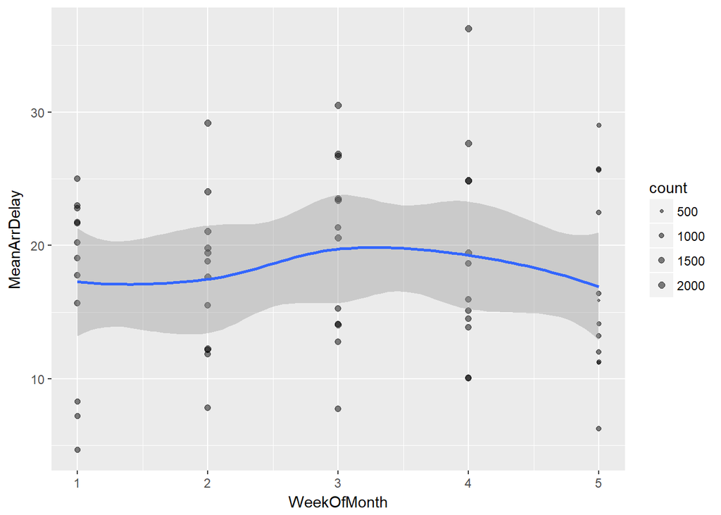

```r
# There is no patteren what so ever. No point in usng this as variable. However, we can try deviding the same by 7 and get the week info to see if there is a patteren.

WeekOfMonthDelay <- tripsplaneairports %>%
  group_by(Month,WeekOfMonth) %>%
  summarise(count=n(), MeanArrDelay = mean(ArrDelay), MeanDepDelay=mean(DepDelay), MeanWeatherDelay2=mean(WeatherDelay)) %>%
  filter ( count > 50, !is.na(MeanArrDelay), !is.na(MeanDepDelay) ) %>%
  collect


ggplot(WeekOfMonthDelay, aes(WeekOfMonth, MeanArrDelay)) + geom_point(aes(size=count), alpha=1/2) + geom_smooth() + scale_size_area(max_size = 2)
```

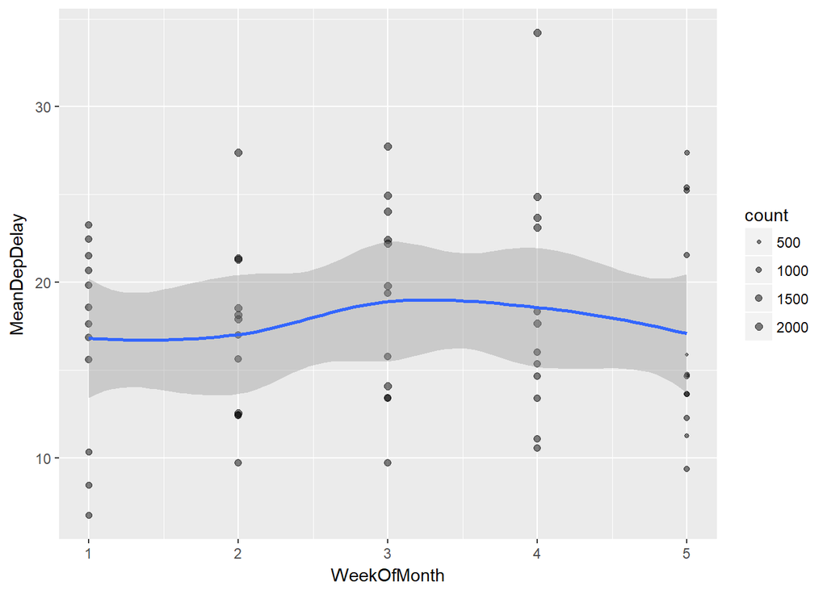

```r
ggplot(WeekOfMonthDelay, aes(WeekOfMonth, MeanDepDelay)) + geom_point(aes(size=count), alpha=1/2) + geom_smooth() + scale_size_area(max_size = 2)
```

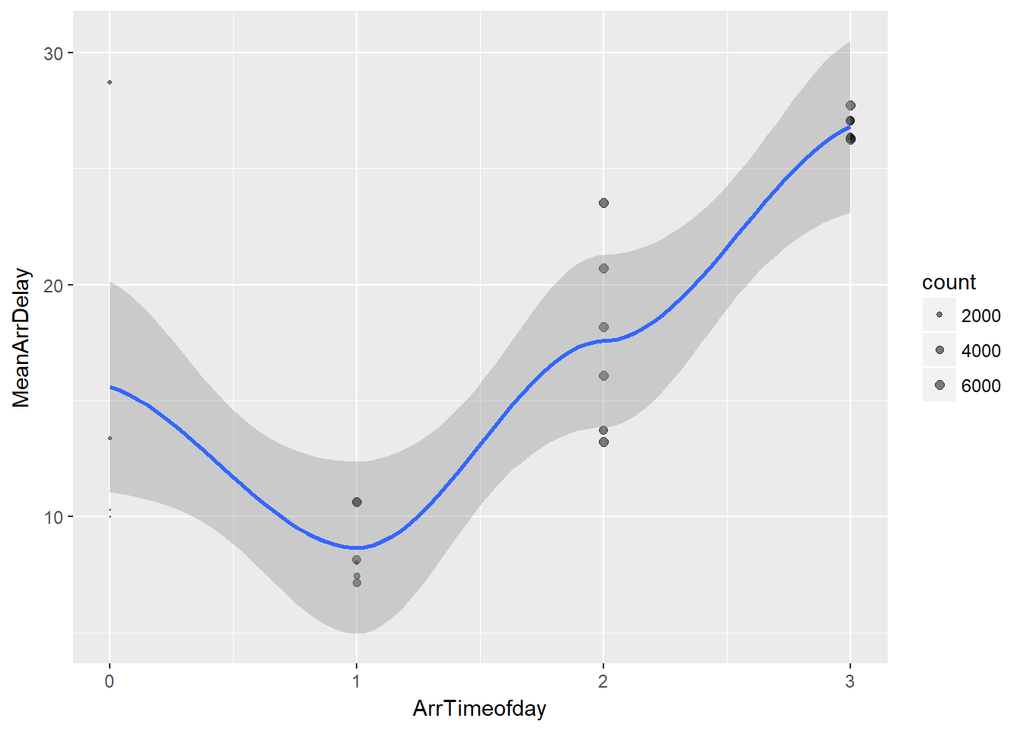

```r
TimeArrDelay <- tripsplaneairports %>%
  group_by(ArrHour,ArrTimeofday) %>%
  summarise(count=n(), MeanArrDelay = mean(ArrDelay), MeanDepDelay=mean(DepDelay), MeanWeatherDelay2=mean(WeatherDelay)) %>%
  filter ( count > 50, !is.na(MeanArrDelay), !is.na(MeanDepDelay) ) %>%
  collect

ggplot(TimeArrDelay, aes(ArrTimeofday, MeanArrDelay)) + geom_point(aes(size=count), alpha=1/2) + geom_smooth() + scale_size_area(max_size = 2)
```

Plan your flight such a way, your sheduled arrival is morning. i.e better overall.

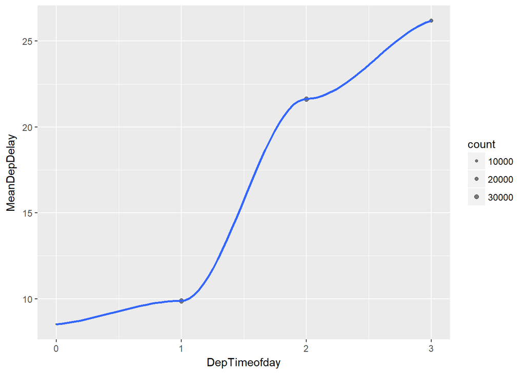

```r
TimeDepDelay <- tripsplaneairports %>%
  group_by(DepTimeofday) %>%
  summarise(count=n(), MeanArrDelay = mean(ArrDelay), MeanDepDelay=mean(DepDelay), MeanWeatherDelay2=mean(WeatherDelay)) %>%
  filter ( count > 50, !is.na(MeanArrDelay), !is.na(MeanDepDelay) ) %>%
  collect

ggplot(TimeDepDelay, aes(DepTimeofday, MeanDepDelay)) + geom_point(aes(size=count), alpha=1/2) + geom_smooth() + scale_size_area(max_size = 2)
```

Generally Departure delays keeps increasing as day prgress. So early morning flights are better.

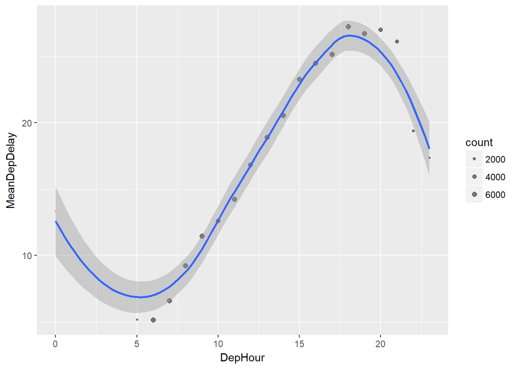

```r
HourDepDelay <- tripsplaneairports %>%
  group_by(DepHour) %>%
  summarise(count=n(), MeanArrDelay = mean(ArrDelay), MeanDepDelay=mean(DepDelay), MeanWeatherDelay2=mean(WeatherDelay)) %>%
  filter ( count > 50, !is.na(MeanArrDelay), !is.na(MeanDepDelay) ) %>%
  collect

ggplot(HourDepDelay, aes(DepHour, MeanDepDelay)) + geom_point(aes(size=count), alpha=1/2) + geom_smooth() + scale_size_area(max_size = 2)
```

Clearly 5-10am departures are better. and almost very negligible delays of less then ~10min.

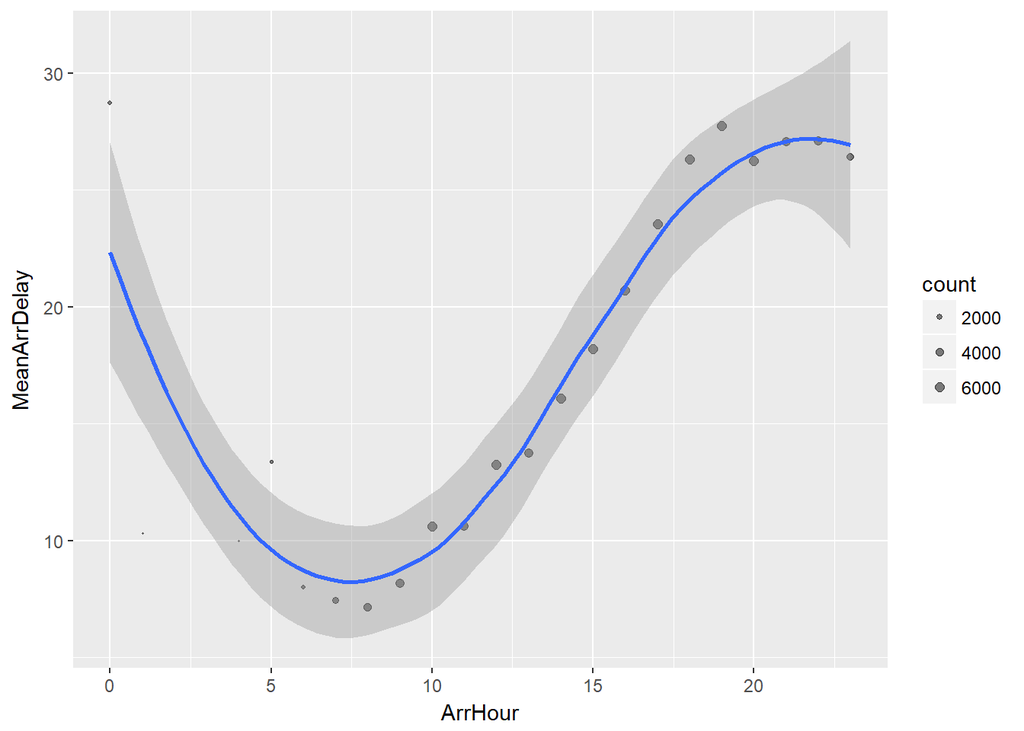

```r
HourArrDelay <- tripsplaneairports %>%
  group_by(ArrHour) %>%
  summarise(count=n(), MeanArrDelay = mean(ArrDelay), MeanDepDelay=mean(DepDelay), MeanWeatherDelay2=mean(WeatherDelay)) %>%
  filter ( count > 50, !is.na(MeanArrDelay), !is.na(MeanDepDelay) ) %>%
  collect

ggplot(HourArrDelay, aes(ArrHour, MeanArrDelay)) + geom_point(aes(size=count), alpha=1/2) + geom_smooth() + scale_size_area(max_size = 2)
```

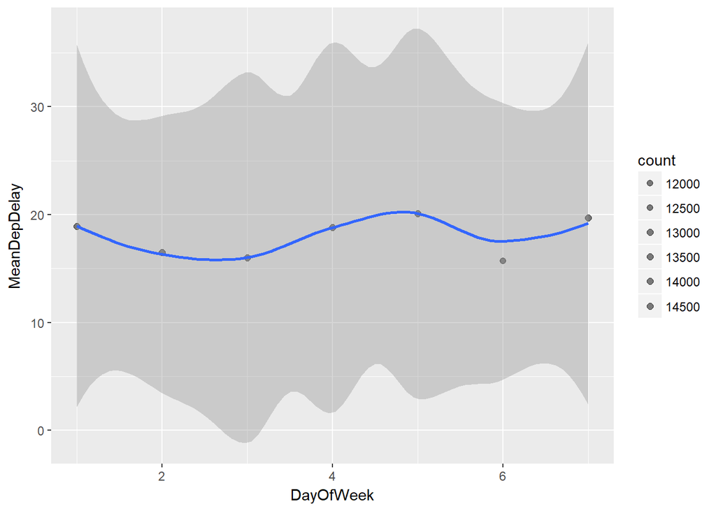

```r
DayOfWeekDelay <- tripsplaneairports %>%
  group_by(DayOfWeek) %>%
  summarise(count=n(), MeanArrDelay = mean(ArrDelay), MeanDepDelay=mean(DepDelay), MeanWeatherDelay2=mean(WeatherDelay)) %>%
  filter ( count > 50, !is.na(MeanArrDelay), !is.na(MeanDepDelay) ) %>%
  collect

ggplot(DayOfWeekDelay, aes(DayOfWeek, MeanDepDelay)) + geom_point(aes(size=count), alpha=1/2) + geom_smooth() + scale_size_area(max_size = 2)
```

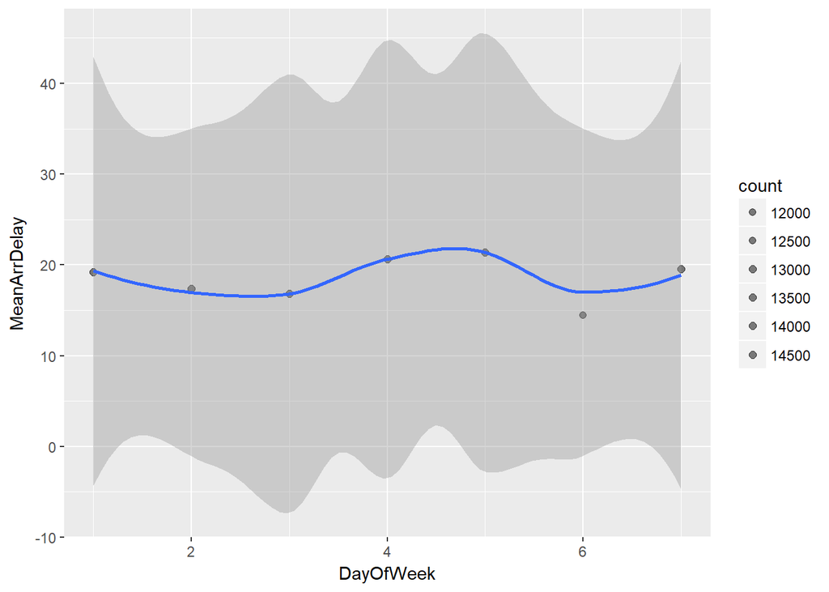

```r
ggplot(DayOfWeekDelay, aes(DayOfWeek, MeanArrDelay)) + geom_point(aes(size=count), alpha=1/2) + geom_smooth() + scale_size_area(max_size = 2)
```

Flight on Saturday seems to be better. Tuesday and Wednesday are ok too. Avoid Friday, Mon and Sun. Same applicable even on Arrival.

#### Best Time of the day: 5am to 10 am is best for both Departure and Arrival: ~ 10 min delay.

Note: This can differ from airport to airport and carrier to carrier. This is in-general with out specifically considering any of the conditions. If, we want to find based on a condition then we can do the same, by using additonal condition.

## Do older planes suffer more delays ?

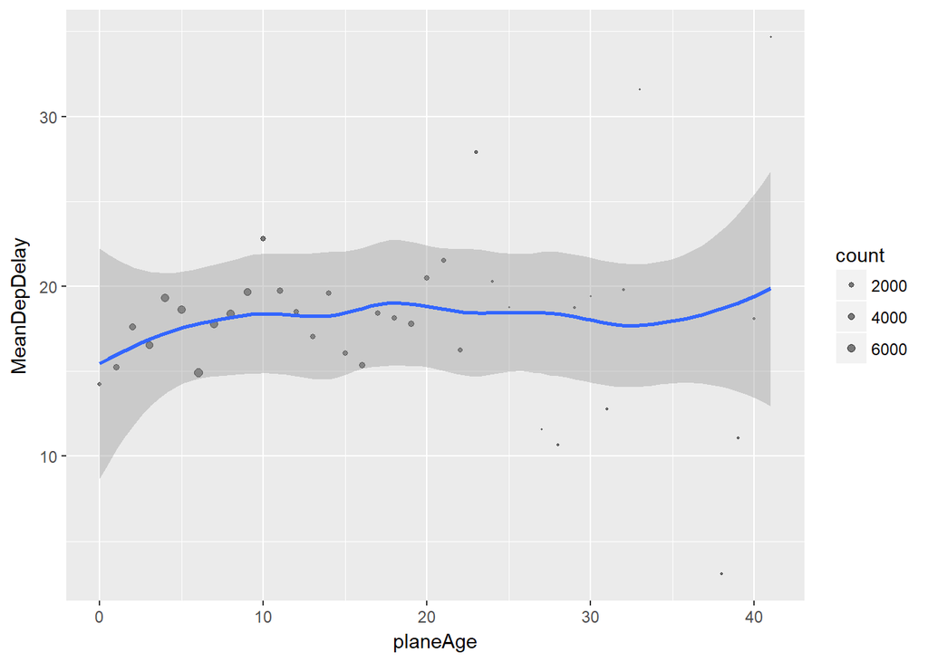

```r
planeAgeDelay <- tripsplaneairports %>%
  filter(planeAge < 1500) %>%
  group_by(planeAge) %>%
  summarise(count=n(), MeanArrDelay = mean(ArrDelay), MeanDepDelay=mean(DepDelay), MeanWeatherDelay2=mean(WeatherDelay)) %>%
  filter ( count > 50, !is.na(MeanArrDelay), !is.na(MeanDepDelay) ) %>%
  collect

ggplot(planeAgeDelay, aes(planeAge, MeanDepDelay)) + geom_point(aes(size=count), alpha=1/2) + geom_smooth() + scale_size_area(max_size = 2)
```

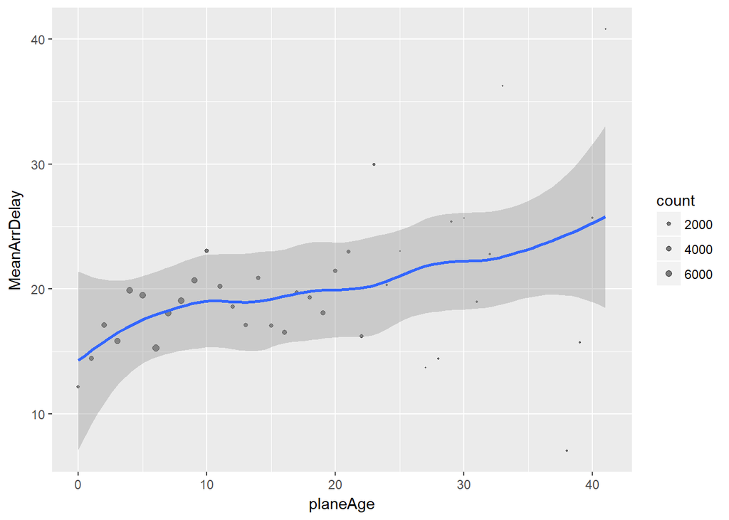

```r
ggplot(planeAgeDelay, aes(planeAge, MeanArrDelay)) + geom_point(aes(size=count), alpha=1/2) + geom_smooth() + scale_size_area(max_size = 2)
```

#### Now let’s look at Airports! This may have importance.

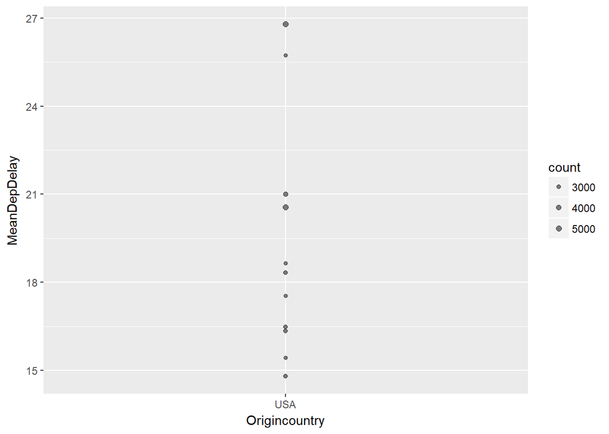

```r
OriginAirportDelay <- tripsplaneairports %>%
  group_by(Origin, Origincity, Originstate, Origincountry) %>%
  summarise(count=n(), MeanArrDelay = mean(ArrDelay), MeanDepDelay=mean(DepDelay), MeanWeatherDelay2=mean(WeatherDelay)) %>%
  filter ( count > 2000, !is.na(MeanArrDelay), !is.na(MeanDepDelay) ) %>%
  collect

# Here increased the count, to study cities/states where major no of trips occoured.

ggplot(OriginAirportDelay, aes(Origincountry, MeanDepDelay)) + geom_point(aes(size=count), alpha=1/2) + geom_smooth() + scale_size_area(max_size = 2)
```

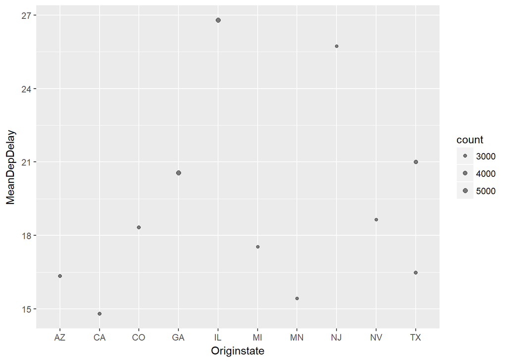

```r
ggplot(OriginAirportDelay, aes(Originstate, MeanDepDelay)) + geom_point(aes(size=count), alpha=1/2) + geom_smooth() + scale_size_area(max_size = 2)
```

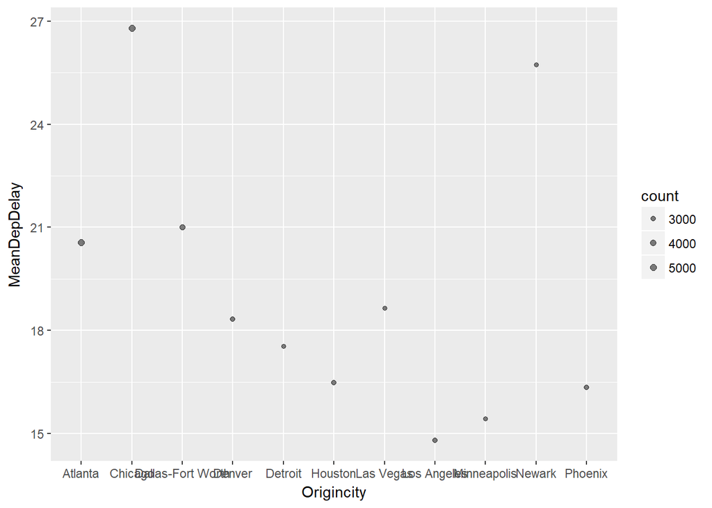

```r
ggplot(OriginAirportDelay, aes(Origincity, MeanDepDelay)) + geom_point(aes(size=count), alpha=1/2) + geom_smooth() + scale_size_area(max_size = 2)
```

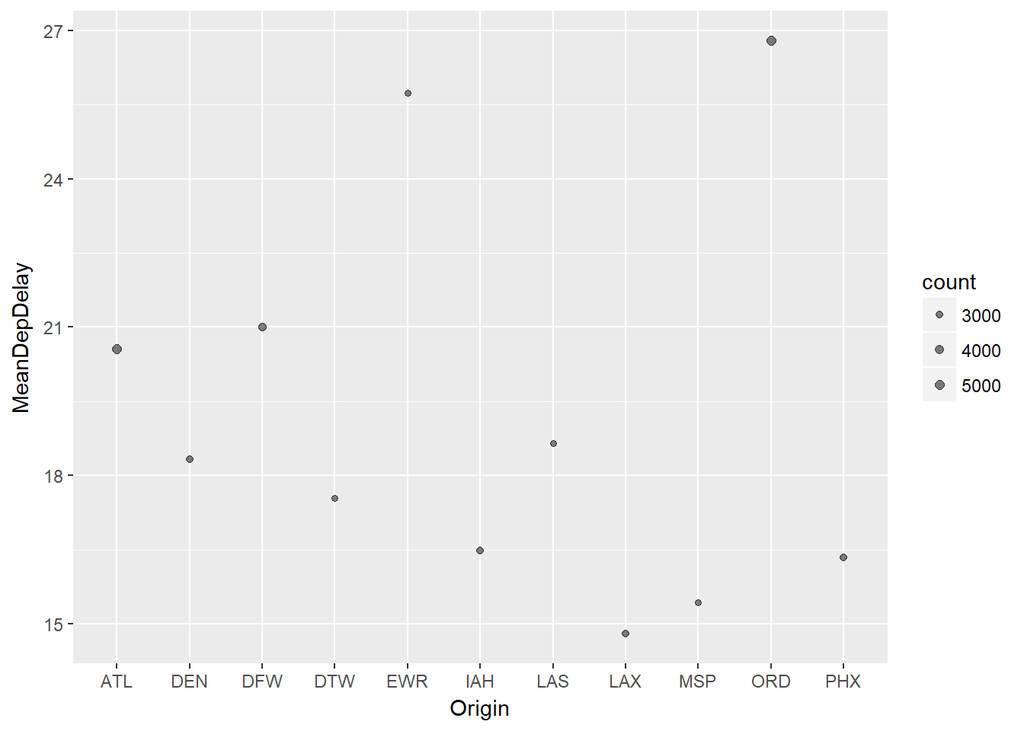

```r
ggplot(OriginAirportDelay, aes(Origin, MeanDepDelay)) + geom_point(aes(size=count), alpha=1/2) + geom_smooth() + scale_size_area(max_size = 2)
```

State seems to have relationship, not country. California seems to be best state and LOSAngles seems to be best city to fly from. Fligts from UT, CA and TN states are better in terms of departure.

```r
str(tripsplaneairports)
```

```
## Classes 'data.table' and 'data.frame':   95496 obs. of  47 variables:
##  $ Dest             : Factor w/ 303 levels "ABE","ABI","ABQ",..: 1 1 1 1 1 1 1 1 1 1 ...
##  $ Origin           : Factor w/ 303 levels "ABE","ABI","ABQ",..: 20 20 20 20 20 20 20 20 20 20 ...
##  $ TailNum          : Factor w/ 5587 levels "80009E","80019E",..: 2019 4683 4695 4791 4791 4809 4819 4853 4943 4963 ...
##  $ Year             : int  2008 2007 2007 2007 2007 2007 2007 2007 2007 2007 ...
##  $ Month            : int  1 9 3 4 5 11 3 9 10 8 ...
##  $ DayofMonth       : int  15 21 28 24 2 24 10 24 15 13 ...
##  $ DayOfWeek        : int  2 5 3 2 3 6 6 1 1 1 ...
##  $ DepTime          : int  2117 2043 937 2150 2106 937 2026 944 2057 1010 ...
##  $ CRSDepTime       : int  2047 2047 937 1952 2040 939 1952 944 2047 944 ...
##  $ ArrTime          : int  2319 2240 1133 2350 2316 1150 2219 1156 2240 1220 ...
##  $ CRSArrTime       : int  2248 2257 1147 2157 2240 1137 2157 1148 2245 1152 ...
##  $ UniqueCarrier    : chr  "OH" "EV" "EV" "EV" ...
##  $ FlightNum        : int  5184 4926 4675 4870 4751 4502 4870 4452 4926 4376 ...
##  $ ActualElapsedTime: int  122 117 116 120 130 133 113 132 103 130 ...
```

[output cut: 35 more lines]

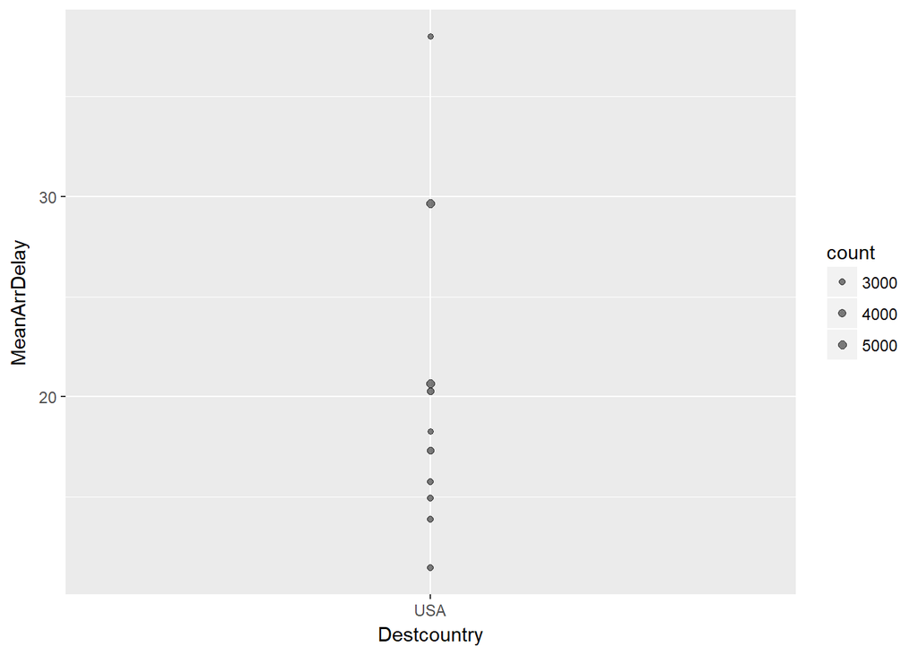

```r
DestAirportDelay <- tripsplaneairports %>%
  group_by(Dest, Destcity, Deststate, Destcountry) %>%
  summarise(count=n(), MeanArrDelay = mean(ArrDelay), MeanDepDelay=mean(DepDelay), MeanWeatherDelay2=mean(WeatherDelay)) %>%
  filter ( count > 2000, !is.na(MeanArrDelay), !is.na(MeanDepDelay) ) %>%
  collect
# Here increased the count, to study cities/states where major no of trips occoured.

ggplot(DestAirportDelay, aes(Destcountry, MeanArrDelay)) + geom_point(aes(size=count), alpha=1/2) + geom_smooth() + scale_size_area(max_size = 2)
```

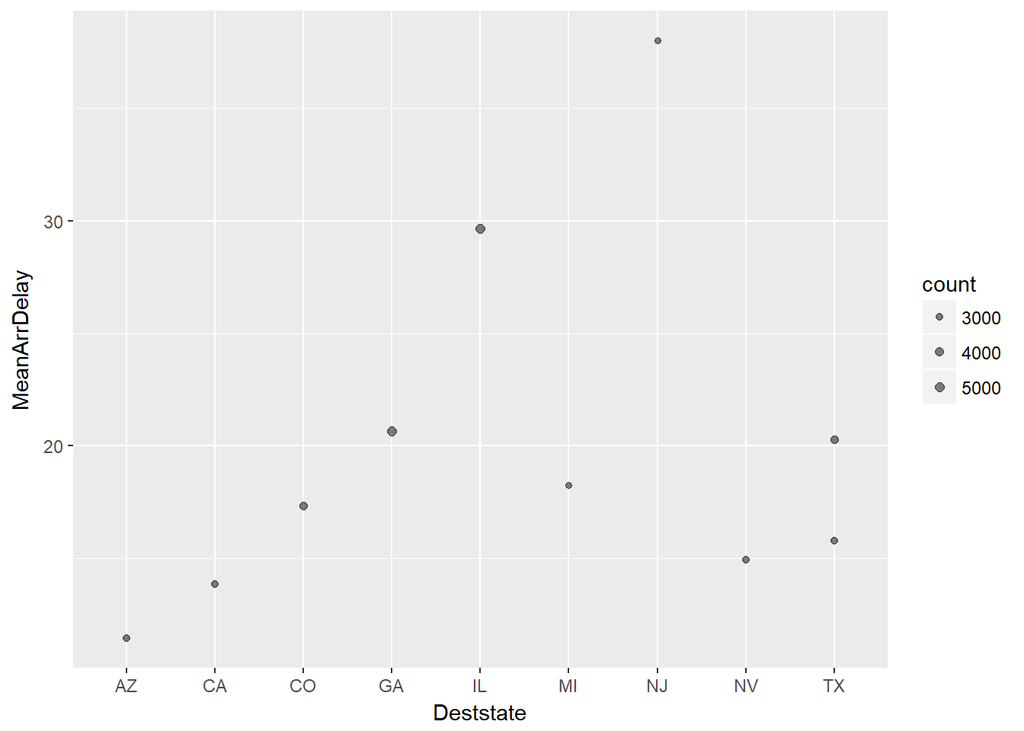

```r
ggplot(DestAirportDelay, aes(Deststate, MeanArrDelay)) + geom_point(aes(size=count), alpha=1/2) + geom_smooth() + scale_size_area(max_size = 2)
```

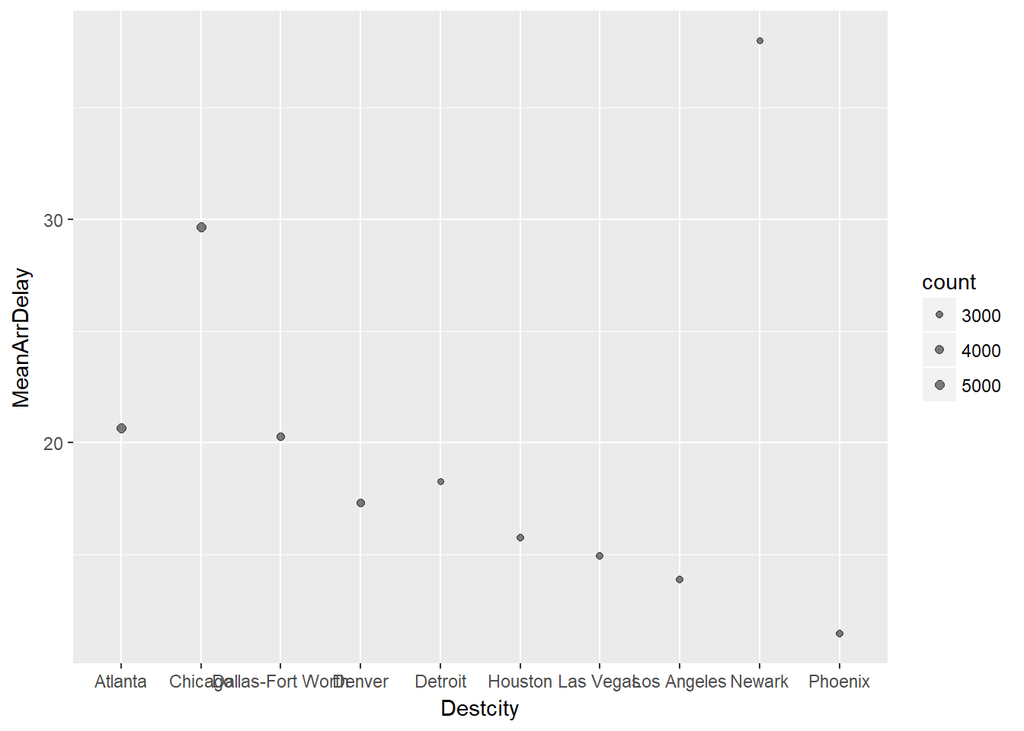

```r
ggplot(DestAirportDelay, aes(Destcity, MeanArrDelay)) + geom_point(aes(size=count), alpha=1/2) + geom_smooth() + scale_size_area(max_size = 2)
```

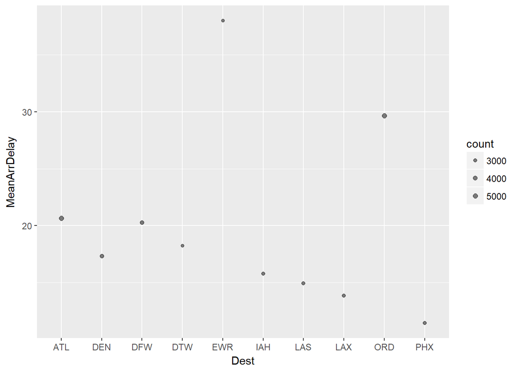

```r
ggplot(DestAirportDelay, aes(Dest, MeanArrDelay)) + geom_point(aes(size=count), alpha=1/2) + geom_smooth() + scale_size_area(max_size = 2)
```

### Let’s plot continous variables and see how they are co-related to each other and to Airline delays.

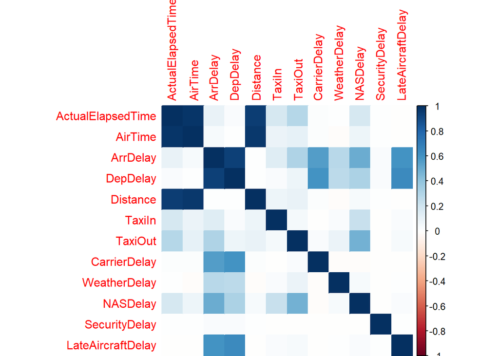

```r
continousdelay <- select(tripsplaneairports, ActualElapsedTime, AirTime, ArrDelay, DepDelay, Distance,
                         TaxiIn, TaxiOut, CarrierDelay, WeatherDelay, NASDelay, SecurityDelay, LateAircraftDelay)
# We can use this as well..
# cont <- sapply(tripsplaneairports, is.numeric)
# tripsplaneairports [, cont]
# How ever if you want to exclude some of the variables then.. manual selection needed
# tripsplaneairports [, -cont] # For remaning , mostly categorical or factor variables.
# If some variables which has numeric values say (1,2,3) for say three different types and should be converted to factor # variables before doing above steps.

tripscorr <- cor(continousdelay, method="pearson")
# Let's plot the co-relation matix
corrplot::corrplot(tripscorr, method="color")
```

### co-relation matix

This clearly provides co-relation between the variables. Now based on exploratory data analysis, we need to choose the variables that are potentially significant and then start the modeling. Based on this plot, we can see ArrDelay has positive co-relation with DepDelay, TaxiOut, CarrierDelay, NASDelay, WeatherDelay, LateAirCraftDelay And DepDelay has positive co-relation wth TaxiOut, CarrierDelay, NASDelay, WeatherDelay, LateAirCraftDelay So, from continous variable point of view, we got the starting point. We can also see that the significant variables are not co-related to each other. i.e there is no multico-linearity.

#### If the multi-colinirity is present, then we should have addressed. i.e combining variables or picking only most significant one and leaving other. PCA is one of the method to address the same. We don’t need here.

Now we have fair idea, now let us see variable significane and based on the results we can choose the best variable combination. We can also statistically, prove what we saw visually befor choosing the final machine learning model.

```r
modeltrips <- na.omit(tripsplaneairports[,c("Dest","Origin", "Month", "DayOfWeek",  "ArrTime", "UniqueCarrier", "ActualElapsedTime", "CRSElapsedTime",
                                    "TaxiOut", "Diverted",  "CarrierDelay", "WeatherDelay",    "NASDelay",        "SecurityDelay",   "LateAircraftDelay" ,"ArrHour",
                                    "DepHour",         "ArrTimeofday",    "DepTimeofday",       "WeekOfMonth",    "Origincity",
                                    "Originstate",   "Destcity", "Deststate" ,  "ArrDelay", "DepDelay" )])
```

#### See each variable, how significant to the DepDelay and ArrDelay

```r
lm.fit1 <- stats::lm(formula = DepDelay ~ factor(Month), data = modeltrips)
summary(lm.fit1)
```

```
##
## Call:
## stats::lm(formula = DepDelay ~ factor(Month), data = modeltrips)
##
## Residuals:
##     Min      1Q  Median      3Q     Max
##  -67.98  -21.33  -14.33    3.86 1100.67
##
## Coefficients:
##                 Estimate Std. Error t value Pr(>|t|)
## (Intercept)      18.2873     0.4787  38.201  < 2e-16 ***
## factor(Month)2    3.5808     0.6861   5.219 1.80e-07 ***
## factor(Month)3    0.9841     0.6708   1.467  0.14240
## factor(Month)4   -1.9595     0.6822  -2.872  0.00408 **
## factor(Month)5   -3.9535     0.6769  -5.841 5.21e-09 ***
## factor(Month)6    4.5839     0.6711   6.831 8.50e-12 ***
## factor(Month)7    4.6881     0.6701   6.996 2.65e-12 ***
## factor(Month)8    1.3438     0.6749   1.991  0.04646 *
## factor(Month)9   -8.1930     0.6953 -11.783  < 2e-16 ***
## factor(Month)10  -6.6280     0.6848  -9.679  < 2e-16 ***
## factor(Month)11  -6.1446     0.6922  -8.877  < 2e-16 ***
## factor(Month)12   6.5450     0.6727   9.729  < 2e-16 ***
## ---
## Signif. codes:  0 '***' 0.001 '**' 0.01 '*' 0.05 '.' 0.1 ' ' 1
##
## Residual standard error: 42.95 on 95358 degrees of freedom
## Multiple R-squared:  0.01172,    Adjusted R-squared:  0.01161
## F-statistic: 102.8 on 11 and 95358 DF,  p-value: < 2.2e-16
```

```r
summary(lm.fit1)$r.squared
```

```
## [1] 0.01172478
```

```r
summary(lm.fit1)$adj.r.squared
```

```
## [1] 0.01161078
```

```r
summary(lm.fit1)$coeff
```

```
##                   Estimate Std. Error    t value      Pr(>|t|)
## (Intercept)     18.2873292  0.4787113  38.201164 6.822364e-317
## factor(Month)2   3.5808300  0.6860688   5.219346  1.799313e-07
## factor(Month)3   0.9840703  0.6708325   1.466939  1.423960e-01
## factor(Month)4  -1.9594603  0.6822256  -2.872159  4.077675e-03
## factor(Month)5  -3.9535407  0.6768740  -5.840882  5.209310e-09
## factor(Month)6   4.5839093  0.6710693   6.830754  8.497322e-12
## factor(Month)7   4.6881148  0.6701257   6.995874  2.653385e-12
## factor(Month)8   1.3438043  0.6748790   1.991178  4.646416e-02
## factor(Month)9  -8.1930234  0.6953495 -11.782598  5.051209e-32
## factor(Month)10 -6.6280285  0.6848092  -9.678650  3.804164e-22
## factor(Month)11 -6.1446269  0.6922195  -8.876703  7.002956e-19
## factor(Month)12  6.5449547  0.6727235   9.729041  2.322190e-22
```

```r
anova(lm.fit1)
```

```
## Analysis of Variance Table
##
## Response: DepDelay
##                  Df    Sum Sq Mean Sq F value    Pr(>F)
## factor(Month)    11   2087022  189729  102.85 < 2.2e-16 ***
## Residuals     95358 175913990    1845
## ---
## Signif. codes:  0 '***' 0.001 '**' 0.01 '*' 0.05 '.' 0.1 ' ' 1
```

Month seems to be significant as evident in EDA.

```r
lm.fit2 <-  stats::lm(formula = DepDelay ~ factor(DepHour) , data = modeltrips)
summary(lm.fit2)
```

[output not shown]

```r
lm.fit3 <-  stats::lm(formula = DepDelay ~ factor(DepTimeofday) , data = modeltrips)
summary(lm.fit3)
```

[output not shown]

```r
lm.fit4 <-  stats::lm(formula = DepDelay ~ factor(Month) +  factor(DepTimeofday) + factor(DepHour), data = modeltrips)
summary(lm.fit4)
```

```
##
## Call:
## stats::lm(formula = DepDelay ~ factor(Month) + factor(DepTimeofday) +
##     factor(DepHour), data = modeltrips)
##
## Residuals:
##     Min      1Q  Median      3Q     Max
##  -73.47  -21.13  -11.68    3.00 1095.49
##
## Coefficients: (3 not defined because of singularities)
##                       Estimate Std. Error t value Pr(>|t|)
## (Intercept)            13.9253     3.7407   3.723 0.000197 ***
## factor(Month)2          3.6497     0.6761   5.398 6.74e-08 ***
## factor(Month)3          1.0564     0.6611   1.598 0.110068
## factor(Month)4         -1.9551     0.6723  -2.908 0.003639 **
## factor(Month)5         -3.8533     0.6671  -5.777 7.65e-09 ***
## factor(Month)6          4.4880     0.6613   6.787 1.15e-11 ***
## factor(Month)7          4.5606     0.6605   6.905 5.06e-12 ***
## factor(Month)8          1.2846     0.6652   1.931 0.053449 .
## factor(Month)9         -7.9338     0.6853 -11.577  < 2e-16 ***
## factor(Month)10        -6.3602     0.6750  -9.423  < 2e-16 ***
## factor(Month)11        -5.8736     0.6822  -8.610  < 2e-16 ***
## factor(Month)12         6.7658     0.6630  10.205  < 2e-16 ***
## factor(DepTimeofday)1   0.4818     3.7504   0.128 0.897778
## factor(DepTimeofday)2  11.3534     3.7477   3.029 0.002451 **
## factor(DepTimeofday)3   3.4557     4.1357   0.836 0.403393
## factor(DepHour)1       10.5269     7.8862   1.335 0.181930
## factor(DepHour)2        1.8451    13.8891   0.133 0.894318
## factor(DepHour)3       18.5336    16.4223   1.129 0.259084
## factor(DepHour)4       22.3119    12.7699   1.747 0.080601 .
## factor(DepHour)5       -8.4821     4.1231  -2.057 0.039668 *
## factor(DepHour)6       -8.9586     0.7615 -11.765  < 2e-16 ***
## factor(DepHour)7       -7.6493     0.7658  -9.989  < 2e-16 ***
## factor(DepHour)8       -4.8794     0.7554  -6.459 1.06e-10 ***
## factor(DepHour)9       -2.6970     0.7635  -3.532 0.000412 ***
## factor(DepHour)10      -1.5458     0.7712  -2.005 0.045017 *
## factor(DepHour)11           NA         NA      NA       NA
## factor(DepHour)12      -8.2392     0.7574 -10.879  < 2e-16 ***
## factor(DepHour)13      -6.1675     0.7412  -8.321  < 2e-16 ***
## factor(DepHour)14      -4.6670     0.7534  -6.195 5.85e-10 ***
## factor(DepHour)15      -1.9150     0.7535  -2.542 0.011039 *
## factor(DepHour)16      -0.6446     0.7382  -0.873 0.382489
## factor(DepHour)17           NA         NA      NA       NA
## factor(DepHour)18      10.1109     1.9039   5.311 1.09e-07 ***
## factor(DepHour)19       9.5068     1.9051   4.990 6.04e-07 ***
## factor(DepHour)20       9.8056     1.9417   5.050 4.42e-07 ***
## factor(DepHour)21       8.6410     1.9611   4.406 1.05e-05 ***
## factor(DepHour)22       1.9987     2.2081   0.905 0.365371
## factor(DepHour)23           NA         NA      NA       NA
## ---
## Signif. codes:  0 '***' 0.001 '**' 0.01 '*' 0.05 '.' 0.1 ' ' 1
##
## Residual standard error: 42.32 on 95335 degrees of freedom
## Multiple R-squared:  0.04071,    Adjusted R-squared:  0.04036
## F-statistic:   119 on 34 and 95335 DF,  p-value: < 2.2e-16
```

This combination seems to be significatnt, Adj R Squared is increasing…

```r
lm.fit5 <-  stats::lm(formula = DepDelay ~ factor(Month) +  factor(DepTimeofday) + factor(DepHour)+ factor(DayOfWeek) + factor(WeekOfMonth), data = modeltrips)
summary(lm.fit5)
```

```
##
## Call:
## stats::lm(formula = DepDelay ~ factor(Month) + factor(DepTimeofday) +
##     factor(DepHour) + factor(DayOfWeek) + factor(WeekOfMonth),
##     data = modeltrips)
##
## Residuals:
##     Min      1Q  Median      3Q     Max
##  -73.65  -21.09  -11.64    3.05 1094.29
##
## Coefficients: (3 not defined because of singularities)
##                       Estimate Std. Error t value Pr(>|t|)
## (Intercept)           14.08755    3.76087   3.746 0.000180 ***
## factor(Month)2         3.44678    0.67696   5.092 3.56e-07 ***
## factor(Month)3         0.92837    0.66111   1.404 0.160241
## factor(Month)4        -2.08777    0.67235  -3.105 0.001902 **
## factor(Month)5        -3.91042    0.66674  -5.865 4.51e-09 ***
## factor(Month)6         4.35050    0.66149   6.577 4.83e-11 ***
## factor(Month)7         4.48710    0.66026   6.796 1.08e-11 ***
## factor(Month)8         1.17050    0.66496   1.760 0.078367 .
## factor(Month)9        -8.07397    0.68553 -11.778  < 2e-16 ***
## factor(Month)10       -6.40531    0.67450  -9.496  < 2e-16 ***
## factor(Month)11       -6.04515    0.68219  -8.861  < 2e-16 ***
## factor(Month)12        6.64827    0.66286  10.030  < 2e-16 ***
## factor(DepTimeofday)1  0.50179    3.74752   0.134 0.893482
## factor(DepTimeofday)2 11.32460    3.74486   3.024 0.002495 **
## factor(DepTimeofday)3  3.44345    4.13251   0.833 0.404700
## factor(DepHour)1      10.58184    7.88034   1.343 0.179335
## factor(DepHour)2       2.14160   13.87885   0.154 0.877368
## factor(DepHour)3      18.82450   16.40951   1.147 0.251314
## factor(DepHour)4      22.26214   12.76044   1.745 0.081054 .
## factor(DepHour)5      -8.48006    4.11989  -2.058 0.039562 *
## factor(DepHour)6      -8.90526    0.76109 -11.701  < 2e-16 ***
## factor(DepHour)7      -7.59241    0.76529  -9.921  < 2e-16 ***
## factor(DepHour)8      -4.88123    0.75492  -6.466 1.01e-10 ***
## factor(DepHour)9      -2.63567    0.76299  -3.454 0.000552 ***
## factor(DepHour)10     -1.53407    0.77056  -1.991 0.046500 *
## factor(DepHour)11           NA         NA      NA       NA
## factor(DepHour)12     -8.17819    0.75688 -10.805  < 2e-16 ***
## factor(DepHour)13     -6.13271    0.74069  -8.280  < 2e-16 ***
```

[output cut: 11 more lines]

```
## factor(DayOfWeek)3    -2.74042    0.50501  -5.426 5.76e-08 ***
## factor(DayOfWeek)4    -0.20127    0.50413  -0.399 0.689718
## factor(DayOfWeek)5     1.11026    0.49919   2.224 0.026142 *
## factor(DayOfWeek)6    -2.81182    0.52977  -5.308 1.11e-07 ***
## factor(DayOfWeek)7     0.09279    0.50879   0.182 0.855294
## factor(WeekOfMonth)2   0.10468    0.42088   0.249 0.803580
## factor(WeekOfMonth)3   1.98820    0.42081   4.725 2.31e-06 ***
## factor(WeekOfMonth)4   1.64039    0.42262   3.881 0.000104 ***
## factor(WeekOfMonth)5   0.25076    0.51476   0.487 0.626157
## ---
## Signif. codes:  0 '***' 0.001 '**' 0.01 '*' 0.05 '.' 0.1 ' ' 1
##
## Residual standard error: 42.29 on 95325 degrees of freedom
## Multiple R-squared:  0.04232,    Adjusted R-squared:  0.04188
## F-statistic: 95.74 on 44 and 95325 DF,  p-value: < 2.2e-16
```

The Adj R Square is increasing…

Out of above variables, Month and DepHour seems to be predicting better.

```r
lm.fit.com.3 <- stats::lm(formula = DepDelay ~  factor(Month) +  factor(DepTimeofday) + factor(DepHour)+ factor(DayOfWeek) + factor(WeekOfMonth) +  factor(ArrHour) , data = modeltrips)
summary(lm.fit.com.3)
```

```
##
## Call:
## stats::lm(formula = DepDelay ~ factor(Month) + factor(DepTimeofday) +
##     factor(DepHour) + factor(DayOfWeek) + factor(WeekOfMonth) +
##     factor(ArrHour), data = modeltrips)
##
## Residuals:
##     Min      1Q  Median      3Q     Max
##  -74.84  -20.91  -11.51    3.02 1090.34
##
## Coefficients: (3 not defined because of singularities)
##                        Estimate Std. Error t value Pr(>|t|)
## (Intercept)            30.82750    4.27384   7.213 5.51e-13 ***
## factor(Month)2          3.43446    0.67624   5.079 3.81e-07 ***
## factor(Month)3          0.87710    0.66043   1.328 0.184157
## factor(Month)4         -2.12252    0.67166  -3.160 0.001578 **
## factor(Month)5         -3.92561    0.66606  -5.894 3.79e-09 ***
## factor(Month)6          4.30888    0.66084   6.520 7.05e-11 ***
## factor(Month)7          4.44480    0.65963   6.738 1.61e-11 ***
## factor(Month)8          1.16914    0.66430   1.760 0.078417 .
## factor(Month)9         -8.09080    0.68483 -11.814  < 2e-16 ***
## factor(Month)10        -6.41971    0.67381  -9.528  < 2e-16 ***
## factor(Month)11        -6.16394    0.68155  -9.044  < 2e-16 ***
## factor(Month)12         6.58353    0.66226   9.941  < 2e-16 ***
## factor(DepTimeofday)1   0.87224    4.00829   0.218 0.827735
## factor(DepTimeofday)2   3.05866    4.00882   0.763 0.445476
## factor(DepTimeofday)3   0.63772    4.20030   0.152 0.879323
## factor(DepHour)1       10.43362    7.88926   1.323 0.186002
## factor(DepHour)2        1.92623   13.87484   0.139 0.889586
## factor(DepHour)3       19.19685   16.45016   1.167 0.243225
## factor(DepHour)4       22.66423   12.80609   1.770 0.076763 .
## factor(DepHour)5       -7.71064    4.22539  -1.825 0.068029 .
## factor(DepHour)6       -8.03664    1.11616  -7.200 6.05e-13 ***
## factor(DepHour)7       -6.26877    1.03452  -6.060 1.37e-09 ***
## factor(DepHour)8       -3.66132    0.95229  -3.845 0.000121 ***
## factor(DepHour)9       -1.66879    0.89235  -1.870 0.061472 .
## factor(DepHour)10      -0.84739    0.80943  -1.047 0.295151
## factor(DepHour)11            NA         NA      NA       NA
## factor(DepHour)12      -0.13027    1.02890  -0.127 0.899245
## factor(DepHour)13       0.78090    0.97480   0.801 0.423080
```

[output cut: 34 more lines]

```
## factor(ArrHour)15     -15.80974    1.88277  -8.397  < 2e-16 ***
## factor(ArrHour)16     -14.68592    1.85521  -7.916 2.48e-15 ***
## factor(ArrHour)17     -11.96142    1.83213  -6.529 6.67e-11 ***
## factor(ArrHour)18      -9.49191    1.80658  -5.254 1.49e-07 ***
## factor(ArrHour)19      -7.56384    1.78370  -4.241 2.23e-05 ***
## factor(ArrHour)20      -8.24946    1.75382  -4.704 2.56e-06 ***
## factor(ArrHour)21      -6.74034    1.74520  -3.862 0.000112 ***
## factor(ArrHour)22      -4.04507    1.72840  -2.340 0.019268 *
## factor(ArrHour)23      -3.43459    1.76623  -1.945 0.051828 .
## ---
## Signif. codes:  0 '***' 0.001 '**' 0.01 '*' 0.05 '.' 0.1 ' ' 1
##
## Residual standard error: 42.24 on 95302 degrees of freedom
## Multiple R-squared:  0.04469,    Adjusted R-squared:  0.04402
## F-statistic: 66.55 on 67 and 95302 DF,  p-value: < 2.2e-16
```

Very different insight. Scheduled ArrHour is better predictor to DepDelay then compared with Secheduled DepHour. The difference is not huge though.

```r
lm.fit6 <-  stats::lm(formula = DepDelay ~ factor(UniqueCarrier),  data = modeltrips)
summary(lm.fit6)
```

```
##
## Call:
## stats::lm(formula = DepDelay ~ factor(UniqueCarrier), data = modeltrips)
##
## Residuals:
##     Min      1Q  Median      3Q     Max
##  -61.62  -21.33  -15.62    4.26 1093.64
##
## Coefficients:
##                         Estimate Std. Error t value Pr(>|t|)
## (Intercept)              15.9773     0.7756  20.599  < 2e-16 ***
## factor(UniqueCarrier)AA   5.3789     0.9060   5.937 2.91e-09 ***
## factor(UniqueCarrier)AQ -14.6942     2.1042  -6.983 2.90e-12 ***
## factor(UniqueCarrier)AS  -1.1323     1.2289  -0.921 0.356853
## factor(UniqueCarrier)B6   9.0212     1.1522   7.830 4.94e-15 ***
## factor(UniqueCarrier)CO   3.2167     1.0197   3.155 0.001607 **
## factor(UniqueCarrier)DL  -2.1908     0.9488  -2.309 0.020949 *
## factor(UniqueCarrier)EV  12.3875     1.0469  11.832  < 2e-16 ***
## factor(UniqueCarrier)F9  -3.5558     1.4336  -2.480 0.013128 *
## factor(UniqueCarrier)FL  -1.2330     1.0758  -1.146 0.251771
## factor(UniqueCarrier)HA -11.9343     1.8552  -6.433 1.26e-10 ***
## factor(UniqueCarrier)MQ   4.3527     0.9347   4.657 3.22e-06 ***
## factor(UniqueCarrier)NW  -1.9548     0.9771  -2.001 0.045445 *
## factor(UniqueCarrier)OH   1.7583     1.0983   1.601 0.109387
## factor(UniqueCarrier)OO  -0.2355     0.9198  -0.256 0.797927
## factor(UniqueCarrier)UA   5.1267     0.9419   5.443 5.25e-08 ***
## factor(UniqueCarrier)US   0.2675     0.9541   0.280 0.779209
## factor(UniqueCarrier)WN   0.6425     0.8522   0.754 0.450891
## factor(UniqueCarrier)XE   3.3494     0.9641   3.474 0.000513 ***
## factor(UniqueCarrier)YV   5.5340     1.0528   5.256 1.47e-07 ***
## ---
## Signif. codes:  0 '***' 0.001 '**' 0.01 '*' 0.05 '.' 0.1 ' ' 1
##
## Residual standard error: 43.03 on 95350 degrees of freedom
## Multiple R-squared:  0.008043,   Adjusted R-squared:  0.007845
## F-statistic: 40.69 on 19 and 95350 DF,  p-value: < 2.2e-16
```

Through p-value they seem to be significant, not when we look for R-squared. Let’s proceed further.

```r
lm.fit7 <-  stats::lm(formula = DepDelay ~ factor(Originstate) ,  data = modeltrips)
summary(lm.fit7)
```

```
##
## Call:
## stats::lm(formula = DepDelay ~ factor(Originstate), data = modeltrips)
##
## Residuals:
##     Min      1Q  Median      3Q     Max
##  -63.43  -21.23  -15.71    4.13 1102.10
##
## Coefficients:
##                        Estimate Std. Error t value Pr(>|t|)
## (Intercept)            15.63692    1.93869   8.066 7.36e-16 ***
## factor(Originstate)AL  -0.01146    2.66974  -0.004 0.996574
## factor(Originstate)AR   6.82920    2.75015   2.483 0.013022 *
## factor(Originstate)AZ  -0.03580    2.09042  -0.017 0.986338
## factor(Originstate)CA  -0.75622    1.98066  -0.382 0.702607
## factor(Originstate)CO   3.07392    2.06437   1.489 0.136481
## factor(Originstate)CT   0.69967    2.87713   0.243 0.807864
## factor(Originstate)DE -14.43692   19.34806  -0.746 0.455567
## factor(Originstate)FL   2.79061    2.01502   1.385 0.166085
## factor(Originstate)GA   5.07246    2.01827   2.513 0.011963 *
## factor(Originstate)HI -12.28850    2.21524  -5.547 2.91e-08 ***
## factor(Originstate)IA   2.03141    2.89471   0.702 0.482825
## factor(Originstate)ID  -6.80744    3.01891  -2.255 0.024140 *
## factor(Originstate)IL   9.41458    2.01081   4.682 2.85e-06 ***
## factor(Originstate)IN   2.39198    2.46705   0.970 0.332263
## factor(Originstate)KS  -0.71192    3.60877  -0.197 0.843614
## factor(Originstate)KY   1.93119    2.18177   0.885 0.376078
## factor(Originstate)LA   2.77432    2.41671   1.148 0.250982
## factor(Originstate)MA   1.72503    2.20697   0.782 0.434436
## factor(Originstate)MD   1.59540    2.26676   0.704 0.481545
## factor(Originstate)ME   9.96557    3.90736   2.550 0.010760 *
## factor(Originstate)MI   2.44284    2.10127   1.163 0.245014
## factor(Originstate)MN  -0.23316    2.15643  -0.108 0.913897
## factor(Originstate)MO   0.54653    2.18971   0.250 0.802905
## factor(Originstate)MS   5.30951    3.22121   1.648 0.099295 .
## factor(Originstate)MT  -8.21246    3.22859  -2.544 0.010971 *
## factor(Originstate)NC   3.13678    2.10211   1.492 0.135648
## factor(Originstate)ND   1.00924    4.24405   0.238 0.812036
## factor(Originstate)NE   4.13081    2.87905   1.435 0.151353
## factor(Originstate)NH   3.03478    3.27883   0.926 0.354673
```

[output cut: 13 more lines]

```
## factor(Originstate)TX   2.17199    1.98561   1.094 0.274017
## factor(Originstate)UT  -4.11298    2.18065  -1.886 0.059282 .
## factor(Originstate)VA   2.62640    2.09458   1.254 0.209880
## factor(Originstate)VI   5.58808    7.07687   0.790 0.429748
## factor(Originstate)VT  16.40012    4.57334   3.586 0.000336 ***
## factor(Originstate)WA  -0.87291    2.21636  -0.394 0.693695
## factor(Originstate)WI   9.22269    2.45774   3.753 0.000175 ***
## factor(Originstate)WV  -5.06549    6.07016  -0.834 0.404007
## factor(Originstate)WY  -0.66753    4.76089  -0.140 0.888494
## ---
## Signif. codes:  0 '***' 0.001 '**' 0.01 '*' 0.05 '.' 0.1 ' ' 1
##
## Residual standard error: 43.05 on 95318 degrees of freedom
## Multiple R-squared:  0.007764,   Adjusted R-squared:  0.007233
## F-statistic: 14.62 on 51 and 95318 DF,  p-value: < 2.2e-16
```

Seems to have some significance

```r
lm.fit7a <-  stats::lm(formula = DepDelay ~  factor(Deststate),  data = modeltrips)
summary(lm.fit7a)
```

```
##
## Call:
## stats::lm(formula = DepDelay ~ factor(Deststate), data = modeltrips)
##
## Residuals:
##     Min      1Q  Median      3Q     Max
##  -66.99  -20.89  -15.65    4.30 1098.30
##
## Coefficients:
##                     Estimate Std. Error t value Pr(>|t|)
## (Intercept)          16.4250     1.8728   8.770  < 2e-16 ***
## factor(Deststate)AL   0.1978     2.5895   0.076  0.93912
## factor(Deststate)AR   4.3491     2.8030   1.552  0.12077
## factor(Deststate)AZ  -2.4760     2.0257  -1.222  0.22161
## factor(Deststate)CA  -1.1590     1.9156  -0.605  0.54516
## factor(Deststate)CO  -0.6938     2.0018  -0.347  0.72889
## factor(Deststate)CT  -0.9861     2.8491  -0.346  0.72925
## factor(Deststate)DE  39.5750    24.8929   1.590  0.11188
## factor(Deststate)FL   1.4369     1.9487   0.737  0.46089
## factor(Deststate)GA   2.6668     1.9600   1.361  0.17364
## factor(Deststate)HI -10.0405     2.1547  -4.660 3.17e-06 ***
## factor(Deststate)IA   4.0137     2.8351   1.416  0.15687
## factor(Deststate)ID  -5.1813     2.9471  -1.758  0.07873 .
## factor(Deststate)IL   8.2330     1.9480   4.226 2.38e-05 ***
## factor(Deststate)IN   1.3045     2.4385   0.535  0.59267
## factor(Deststate)KS  -1.7777     3.6382  -0.489  0.62511
## factor(Deststate)KY  -0.2789     2.1332  -0.131  0.89599
## factor(Deststate)LA   3.1227     2.3964   1.303  0.19254
## factor(Deststate)MA   4.6308     2.1574   2.147  0.03183 *
## factor(Deststate)MD   0.4128     2.2040   0.187  0.85143
## factor(Deststate)ME   2.4281     4.0539   0.599  0.54920
## factor(Deststate)MI   0.4658     2.0490   0.227  0.82015
## factor(Deststate)MN  -1.0665     2.1161  -0.504  0.61426
## factor(Deststate)MO   1.1804     2.1292   0.554  0.57931
## factor(Deststate)MS   2.5112     3.1161   0.806  0.42032
## factor(Deststate)MT  -5.3473     3.2177  -1.662  0.09655 .
## factor(Deststate)NC   1.3793     2.0377   0.677  0.49848
## factor(Deststate)ND   3.1370     4.1231   0.761  0.44676
## factor(Deststate)NE  -0.4228     2.7730  -0.152  0.87882
## factor(Deststate)NH   4.3623     3.2256   1.352  0.17626
```

[output cut: 13 more lines]

```
## factor(Deststate)TX   0.2707     1.9212   0.141  0.88794
## factor(Deststate)UT  -4.1879     2.1223  -1.973  0.04846 *
## factor(Deststate)VA   2.2949     2.0346   1.128  0.25936
## factor(Deststate)VI  15.2579     6.9708   2.189  0.02861 *
## factor(Deststate)VT  19.7877     4.8137   4.111 3.95e-05 ***
## factor(Deststate)WA  -0.6683     2.1427  -0.312  0.75511
## factor(Deststate)WI   4.6941     2.3941   1.961  0.04992 *
## factor(Deststate)WV   6.5750     6.0923   1.079  0.28049
## factor(Deststate)WY  -3.2432     4.3340  -0.748  0.45427
## ---
## Signif. codes:  0 '***' 0.001 '**' 0.01 '*' 0.05 '.' 0.1 ' ' 1
##
## Residual standard error: 42.99 on 95318 degrees of freedom
## Multiple R-squared:  0.01017,    Adjusted R-squared:  0.009639
## F-statistic:  19.2 on 51 and 95318 DF,  p-value: < 2.2e-16
```

Seems to have some significance

```r
lm.fit7c <-  stats::lm(formula = DepDelay ~ factor(Originstate) + factor(Deststate) + factor(UniqueCarrier),  data = modeltrips)
summary(lm.fit7c)
```

```
##
## Call:
## stats::lm(formula = DepDelay ~ factor(Originstate) + factor(Deststate) +
##     factor(UniqueCarrier), data = modeltrips)
##
## Residuals:
##     Min      1Q  Median      3Q     Max
##  -64.92  -20.65  -14.29    4.28 1099.21
##
## Coefficients:
##                           Estimate Std. Error t value Pr(>|t|)
## (Intercept)              16.350145   2.684826   6.090 1.13e-09 ***
## factor(Originstate)AL    -1.563855   3.172649  -0.493 0.622072
## factor(Originstate)AR     4.848647   3.243437   1.495 0.134941
## factor(Originstate)AZ    -0.005758   2.693403  -0.002 0.998294
## factor(Originstate)CA    -0.613378   2.592517  -0.237 0.812971
## factor(Originstate)CO     3.241073   2.679205   1.210 0.226392
## factor(Originstate)CT    -0.040382   3.343642  -0.012 0.990364
## factor(Originstate)DE   -24.834321  19.329671  -1.285 0.198873
## factor(Originstate)FL     1.058462   2.644735   0.400 0.688999
## factor(Originstate)GA     3.376879   2.698876   1.251 0.210858
## factor(Originstate)HI   -11.913993   3.156754  -3.774 0.000161 ***
## factor(Originstate)IA    -0.812816   3.366559  -0.241 0.809216
## factor(Originstate)ID    -5.168806   3.479688  -1.485 0.137435
## factor(Originstate)IL     7.608771   2.637176   2.885 0.003913 **
## factor(Originstate)IN     1.015818   3.006307   0.338 0.735443
## factor(Originstate)KS    -2.539159   3.984570  -0.637 0.523965
## factor(Originstate)KY     0.430524   2.806995   0.153 0.878102
## factor(Originstate)LA     1.814443   2.964473   0.612 0.540498
## factor(Originstate)MA    -0.292904   2.796558  -0.105 0.916584
## factor(Originstate)MD     1.869617   2.846478   0.657 0.511300
## factor(Originstate)ME     3.788516   4.263857   0.889 0.374264
## factor(Originstate)MI     2.911444   2.749034   1.059 0.289567
## factor(Originstate)MN     1.566421   2.797727   0.560 0.575555
## factor(Originstate)MO    -0.173411   2.772913  -0.063 0.950135
## factor(Originstate)MS     3.331822   3.650622   0.913 0.361417
## factor(Originstate)MT    -6.008553   3.678647  -1.633 0.102397
## factor(Originstate)NC     0.777541   2.719875   0.286 0.774975
## factor(Originstate)ND     2.285131   4.584642   0.498 0.618181
## factor(Originstate)NE     2.108551   3.341007   0.631 0.527968
```

[output cut: 84 more lines]

```
## factor(UniqueCarrier)MQ   2.235542   1.125259   1.987 0.046960 *
## factor(UniqueCarrier)NW  -2.595335   1.011142  -2.567 0.010268 *
## factor(UniqueCarrier)OH   1.342387   1.325801   1.013 0.311297
## factor(UniqueCarrier)OO   1.221508   1.157737   1.055 0.291390
## factor(UniqueCarrier)UA   3.650202   1.179224   3.095 0.001966 **
## factor(UniqueCarrier)US   0.124818   1.181765   0.106 0.915884
## factor(UniqueCarrier)WN   1.226249   1.075367   1.140 0.254161
## factor(UniqueCarrier)XE  -0.424844   1.166128  -0.364 0.715620
## factor(UniqueCarrier)YV   6.217081   1.254555   4.956 7.22e-07 ***
## ---
## Signif. codes:  0 '***' 0.001 '**' 0.01 '*' 0.05 '.' 0.1 ' ' 1
##
## Residual standard error: 42.79 on 95248 degrees of freedom
## Multiple R-squared:  0.02009,    Adjusted R-squared:  0.01885
## F-statistic: 16.14 on 121 and 95248 DF,  p-value: < 2.2e-16
```

Combining them is better, these seem to be significant.

```r
lm.fit8 <-  stats::lm(formula = DepDelay ~ factor(Origin),  data = modeltrips)
summary(lm.fit8)
```

[output not shown]

```r
lm.fit8a <-  stats::lm(formula = DepDelay ~ factor(Dest),  data = modeltrips)
summary(lm.fit8a)
```

[output not shown]

```r
lm.fit9 <-  stats::lm(formula = DepDelay ~ factor(Origincity),  data = modeltrips)
summary(lm.fit9)
```

[output not shown]

```r
lm.fit9a <-  stats::lm(formula = DepDelay ~ factor(Destcity),  data = modeltrips)
summary(lm.fit9a)
```

[output not shown]

```r
lm.fit9b <-  stats::lm(formula = DepDelay ~ factor(Origincity) + factor(Destcity),  data = modeltrips)
summary(lm.fit9b)
AIC(lm.fit9b)
BIC(lm.fit9b)
```

[output not shown]

```r
lm.fit10 <-  stats::lm(formula = DepDelay ~ Diverted,  data = modeltrips)
summary(lm.fit10)
```

[output not shown]

### Factors and Dummy variables for all significant catagorical variables in the data

Since lm model auto creates required factors for catagorical variables. So we don’t exclusively need to create theem.

```r
tripsplaneairports <- na.omit(tripsplaneairports)
tripsdummy <- model.matrix(~ as.factor(Month)+as.factor(DayOfWeek)+UniqueCarrier
                          +as.factor(DepHour)+ as.factor(WeekOfMonth)
                          +as.factor(ArrHour) + as.factor(Deststate) + as.factor(Originstate) ,data=tripsplaneairports)
tripsdummy <- tripsdummy[,-1]

#Instead take all other significant variables here..

# This was to test without creating dummy variables...
#tripscatogorical <- tripsplaneairports[, c( "Month", "DayOfWeek", "UniqueCarrier", "DepHour", "DepTimeofday" , #"WeekOfMonth" , "ArrHour", "ArrTimeofday" , "Deststate" , "Originstate" )]

#tripscatogorical <- tripscatogorical %>% mutate_if(is.integer,as.factor)
#tripscatogorical <- tripscatogorical %>% mutate_if(is.character,as.factor)
#tripscatogorical <- tripscatogorical %>% mutate_if(is.numeric, as.factor)

# Based on the co-relations in EDA
tripscontinous <- tripsplaneairports[, c( "TaxiOut", "CarrierDelay", "WeatherDelay", "NASDelay", "LateAircraftDelay" )]
```

Scaling all continous independent variables excluding Dependent variables.

```r
tripscontinous <- as.data.frame(scale (tripscontinous)) # substract mean and devide by SD


tripscontinous$ArrDelay <- tripsplaneairports$ArrDelay
tripscontinous$DepDelay <- tripsplaneairports$DepDelay
tripscontinous <- as.data.frame(tripscontinous)

# Now let's combine trips tripscontinous, tripscatogorical
nrow(tripscontinous)
```

```
## [1] 82222
```

```r
tripsnew <- cbind(tripsdummy, tripscontinous )
tripsnew <- as.data.frame(tripsnew)
```

## Create a model to predict flight delays

### Modeling - Apply leniar regression to predict Departure Delays and Arrival Delays

#### Let’s start with Departure Delays.

Removing Arrvilal related variables.

```r
traintripsdep <- traintrips[, !grepl("ArrDelay" , names(traintrips))]

#lm.dep.fit_ini1 <- stats::lm(DepDelay ~ as.factor(Month)+as.factor(DayOfWeek)+UniqueCarrier
#                         +as.factor(DepHour)+as.factor(DepTimeofday) + as.factor(WeekOfMonth)
#                       +as.factor(ArrHour) + as.factor(ArrTimeofday) +
#                        as.factor(Deststate) + as.factor(Originstate) , data=traintripsdep)
#summary(lm.dep.fit_ini1)

#lm.dep.fit_ini2 <- stats::lm( DepDelay ~ TaxiOut + CarrierDelay + WeatherDelay + NASDelay + LateAircraftDelay , #data=traintripsdep)
#summary(lm.dep.fit_ini2)

lm.dep.fit1 <- stats::lm(DepDelay ~ . , data=traintripsdep)

summary(lm.dep.fit1)
```

```
##
## Call:
## stats::lm(formula = DepDelay ~ ., data = traintripsdep)
##
## Residuals:
##     Min      1Q  Median      3Q     Max
## -98.781  -5.198  -0.533   4.839 168.322
##
## Coefficients: (9 not defined because of singularities)
##                             Estimate Std. Error  t value Pr(>|t|)
## (Intercept)                17.007876   1.809683    9.398  < 2e-16 ***
## `as.factor(Month)2`        -0.022176   0.257114   -0.086 0.931267
## `as.factor(Month)3`         0.377983   0.249010    1.518 0.129037
## `as.factor(Month)4`        -0.280444   0.250054   -1.122 0.262068
## `as.factor(Month)5`        -0.284172   0.250522   -1.134 0.256667
## `as.factor(Month)6`         0.527433   0.248727    2.121 0.033968 *
## `as.factor(Month)7`         0.949969   0.248083    3.829 0.000129 ***
## `as.factor(Month)8`         0.950921   0.248627    3.825 0.000131 ***
## `as.factor(Month)9`        -0.546044   0.257389   -2.121 0.033888 *
## `as.factor(Month)10`       -0.028194   0.253336   -0.111 0.911385
## `as.factor(Month)11`        0.191874   0.254888    0.753 0.451587
## `as.factor(Month)12`        0.468576   0.249310    1.879 0.060185 .
## `as.factor(DayOfWeek)2`    -0.604315   0.184405   -3.277 0.001050 **
## `as.factor(DayOfWeek)3`    -0.365805   0.184112   -1.987 0.046944 *
## `as.factor(DayOfWeek)4`    -0.294505   0.183255   -1.607 0.108045
## `as.factor(DayOfWeek)5`     0.396773   0.181335    2.188 0.028670 *
## `as.factor(DayOfWeek)6`    -0.272680   0.193252   -1.411 0.158250
## `as.factor(DayOfWeek)7`    -0.133137   0.185082   -0.719 0.471934
## UniqueCarrierAQ            -1.215011   0.933024   -1.302 0.192846
## UniqueCarrierAS            -1.904191   0.507581   -3.751 0.000176 ***
## UniqueCarrierB6             0.628311   0.405138    1.551 0.120944
## UniqueCarrierCO             1.832165   0.343101    5.340 9.34e-08 ***
## UniqueCarrierDL             0.325368   0.352675    0.923 0.356236
## UniqueCarrierEV             1.369069   0.428304    3.196 0.001392 **
## UniqueCarrierF9            -0.865397   0.504013   -1.717 0.085984 .
## UniqueCarrierFL            -3.733817   0.391283   -9.543  < 2e-16 ***
## UniqueCarrierHA            -3.020768   0.864673   -3.494 0.000477 ***
## UniqueCarrierMQ            -1.378832   0.303717   -4.540 5.65e-06 ***
## UniqueCarrierNW            -1.260690   0.410984   -3.067 0.002160 **
## UniqueCarrierOH             0.837489   0.420792    1.990 0.046568 *
```

[output cut: 162 more lines]

```
## `as.factor(Originstate)WA`  2.909176   0.936572    3.106 0.001896 **
## `as.factor(Originstate)WI`  1.972829   1.092509    1.806 0.070960 .
## `as.factor(Originstate)WV` -0.001525   2.354164   -0.001 0.999483
## `as.factor(Originstate)WY` -0.966011   1.742404   -0.554 0.579299
## TaxiOut                    -8.712516   0.063930 -136.283  < 2e-16 ***
## CarrierDelay               25.111078   0.051976  483.129  < 2e-16 ***
## WeatherDelay               11.390397   0.050033  227.659  < 2e-16 ***
## NASDelay                   17.038021   0.059414  286.770  < 2e-16 ***
## LateAircraftDelay          26.895802   0.052803  509.363  < 2e-16 ***
## ---
## Signif. codes:  0 '***' 0.001 '**' 0.01 '*' 0.05 '.' 0.1 ' ' 1
##
## Residual standard error: 10.09 on 40919 degrees of freedom
## Multiple R-squared:  0.9417, Adjusted R-squared:  0.9414
## F-statistic:  3459 on 191 and 40919 DF,  p-value: < 2.2e-16
```

```r
AIC(lm.dep.fit1)
```

```
## [1] 306936.1
```

```r
BIC(lm.dep.fit1)
```

```
## [1] 308600.6
```

[output not shown]

[output not shown]

[output not shown]